# ¡Hola, Rubintel!

Mi nombre es Francisco Benavides, soy code reviewer de Tripleten y voy a revisar el proyecto que acabas de desarrollar.

Cada ves que vea un error por primera vez, lo señalaré. Deberás encontrarlo y arreglarlo, ya que buscamos que te prepares para un trabajo real, en el cual tu líder de equipo hará lo mismo. Si no puedes solucionar el error, te brindaré algunos tips más especificos la proxima vez.

Podrás encontrar mis comentarios más abajo - **por favor, no los muevas, no los modifiques ni los borres**.

¿Cómo lo voy a hacer? Voy a leer cuidadosamente cada una de tus implementaciones que has llevado a cabo para complir con tu informe. Cada uno de mis comentarios tiene el siguiente código de colores:

**Comentario del revisor**

Si todo está perfecto.

**Comentario del revisor**

Si tu código está bien pero se puede mejorar o hay algún detalle que le hace falta.

**Comentario del revisor**

Si de pronto hace falta algo o existe algún problema con tu código o conclusiones.

Si encuentras que es necesario, puedes responderme de esta forma:

**Respuesta del estudiante**

Mucho éxito!

**Comentario del revisor**

Hola Rubintel, gracias por enviar tu proyecto. Hay algunos detalles a corregir/mencionar antes de poder continuar con la corrección. Verifica que tu proyecto sea ejecutable en la plataforma para poder revisar por completo tu proyecto. Tambien hay algunos detalles que no estan trabajados de la mejor forma.

# ⛽ Análisis de Rentabilidad y Selección de Pozos Petroleros

### 📄 Descripción General

El objetivo principal de este proyecto es identificar la mejor ubicación para desarrollar 200 nuevos pozos de petróleo dentro de tres regiones exploradas por **OilyGiant**. Se utilizarán datos geológicos para construir modelos predictivos que estimen el volumen de reservas de petróleo y permitan evaluar tanto la rentabilidad esperada como los riesgos asociados.

#### ⚙️ Parámetros Interactivos

Antes de comenzar el análisis, el usuario puede ajustar los siguientes parámetros clave para personalizar la evaluación:

#### 🔧 Metodología del Proyecto

- 📥 **Preparación de Datos:** Los datos se limpiarán, imputarán los valores faltantes y se normalizarán para garantizar la calidad del análisis.
- 🧠 **Modelos Predictivos:** Se desarrollarán modelos de regresión lineal para estimar el volumen de reservas en cada región.
- 💵 **Análisis Financiero:** Se calculará el beneficio esperado en función del volumen de reservas y el precio de venta ajustado por el usuario.
- 📉 **Análisis de Riesgos:** Se evaluará el riesgo financiero mediante simulaciones de *bootstrapping*, con un nivel de riesgo ajustable por el usuario.

#### 📈 Resultados Esperados

- ✔️ Un modelo predictivo preciso que estime el volumen de reservas de petróleo con una precisión ajustada a las configuraciones seleccionadas.
- 💰 Evaluación de la rentabilidad esperada en cada región, utilizando el precio de venta y volumen de reservas proporcionados por el usuario.
- 📉 Análisis detallado de los riesgos financieros asociados a cada región, ajustado por los niveles de riesgo seleccionados.
- 🏆 Recomendación de la región más rentable para la perforación de nuevos pozos, maximizando el retorno de inversión y minimizando riesgos.

#### 🔍 Conclusiones

Este análisis proporcionará a **OilyGiant** una base sólida para la toma de decisiones estratégicas en la apertura de nuevos pozos petroleros, maximizando la rentabilidad y minimizando los riesgos financieros. A través de la combinación de modelos predictivos y simulaciones ajustadas, se identificarán las mejores oportunidades de desarrollo de pozos.

**Comentario del revisor**

Tu codigo se rompe aca

### Revisión 1

**Respuesta del estudiante**

Se elimino esta seccion por contener errores y no estar lista algunas funcionalidades

# 📦 Instalación y Verificación de Bibliotecas Necesarias

### ⚙️ Descripción General

Este bloque de código está diseñado para instalar y verificar todas las bibliotecas necesarias para el análisis de datos y la visualización. Utiliza módulos como **subprocess** e **importlib** para automatizar el proceso de instalación y comprobar si ya están instaladas en el entorno. Además, proporciona una interfaz interactiva que permite al usuario seleccionar qué bibliotecas instalar.

#### 🔧 Funcionalidades Principales

- 📥 **Verificación de Instalación:** Revisa si una biblioteca está instalada y muestra su versión actual.
- 📦 **Instalación Automática:** Instala las bibliotecas que no estén presentes en el entorno, utilizando el comando `pip install`.
- 🔍 **Notificaciones Interactivas:** Usa mensajes de estado claros y visualmente atractivos para informar al usuario del progreso de la instalación.
- 🧹 **Limpieza de Memoria:** Después de la instalación, libera la memoria no utilizada mediante el recolector de basura (`gc.collect()`).

#### 🚀 Ventajas de la Automatización

- 🔄 **Automatización Completa:** Simplifica el proceso de configuración inicial del entorno, ahorrando tiempo y esfuerzo en la instalación manual.
- 💡 **Selección Personalizada:** Permite a los usuarios seleccionar solo las bibliotecas necesarias para su proyecto, optimizando el entorno de trabajo.
- 🎯 **Feedback Visual Inmediato:** Las notificaciones visuales interactivas mejoran la experiencia del usuario, mostrando de manera clara los resultados de las acciones.
- ⚡ **Optimización de Recursos:** El uso de `gc.collect()` asegura una gestión eficiente de la memoria después de cada operación.

#### 📋 Flujo del Proceso

1. 🛠️ **Verificación de Bibliotecas:** El sistema comprueba si cada biblioteca ya está instalada en el entorno y muestra su versión.
2. 📥 **Instalación de Bibliotecas Faltantes:** Se instala automáticamente cualquier biblioteca que no esté disponible, mostrando notificaciones de progreso.
3. 🔄 **Actualización del Progreso:** Se muestran notificaciones interactivas sobre el estado de cada instalación.
4. 🧹 **Limpieza de Memoria:** Al finalizar, se realiza la limpieza de memoria para liberar recursos innecesarios.

#### 🔍 Conclusión

Este módulo asegura que el entorno de trabajo esté completamente configurado con las bibliotecas necesarias, brindando al usuario una experiencia optimizada y sin interrupciones. La automatización del proceso de instalación ahorra tiempo, mientras que las notificaciones interactivas mantienen informado al usuario sobre el progreso en todo momento.

```python
#import sys
#!{sys.executable} -m pip install --user --upgrade imbalanced-learn scikit-learn rich pandas numpy matplotlib seaborn ipywidgets
```

```python
# Bloque de Instalación e Importación de Bibliotecas
from IPython.display import display, HTML, clear_output
import importlib
import subprocess
import ipywidgets as widgets
import sys
import gc
import time
from datetime import datetime

# Aumentar el límite de recursión
sys.setrecursionlimit(1500)

# Estilos Globales para Notificaciones y Mensajes
estilo_global = """
<style>
    .info-box {
        background-color: #E8F5E9;
        padding: 20px;
        border-left: 5px solid #4CAF50;
        border-radius: 5px;
        font-family: Arial, sans-serif;
        font-size: 16px;
        color: #4CAF50;
        line-height: 1.6;
    }
    .info-box-error {
        background-color: #FDECEA;
        padding: 20px;
        border-left: 5px solid #F44336;
        border-radius: 5px;
        font-family: Arial, sans-serif;
        font-size: 16px;
        color: #F44336;
        line-height: 1.6;
    }
    .process-start, .process-end {
        background-color: #E0F7FA;
        color: #004D40;
        border-left: 5px solid #00ACC1;
        border-radius: 5px;
        padding: 15px;
        margin: 20px 0;
        font-size: 18px;
        text-align: center;
    }
</style>
"""
display(HTML(estilo_global))


# Configuración de visualización para mejorar la revisión de DataFrames en pandas
# Mostrar todas las columnas: Para mostrar todas las columnas de un DataFrame
pd.set_option('display.max_columns', None)
# Evitar división en varias líneas: Si deseas que las filas de tu DataFrame no se dividan en varias líneas
pd.set_option('display.expand_frame_repr', False)
# Mostrar todas las filas: Para mostrar todas las filas de un DataFrame sin límites
pd.set_option('display.max_rows', None)
# Mostrar el ancho completo de las columnas: Si quieres que las columnas se muestren con su ancho completo
pd.set_option('display.max_colwidth', None)

# Verificación de instalación de una biblioteca
def verificar_biblioteca(biblioteca):
    try:
        mod = importlib.import_module(biblioteca)
        version = getattr(mod, "__version__", "versión no disponible")
        return (biblioteca, version, True)
    except ModuleNotFoundError:
        return (biblioteca, "No instalado", False)

# Manejo de errores de importación
def manejar_error_importacion(biblioteca, error):
    mensaje = f"Error al intentar importar {biblioteca}. Detalle del error: {error}"
    display(HTML(f"<div class='info-box-error'><h3>⚠️ Error de Instalación</h3>{mensaje}</div>"))

# Instalación de una biblioteca
def instalar_una_biblioteca(biblioteca):
    resultado = verificar_biblioteca(biblioteca)
    if resultado[2]:
        display(HTML(f"<div class='info-box'>📦 {biblioteca} ya está instalada - Versión: {resultado[1]}</div>"))
        return (biblioteca, True)
    try:
        subprocess.check_call([sys.executable, "-m", "pip", "install", biblioteca])
        display(HTML(f"<div class='info-box'>📦 {biblioteca} instalada correctamente.</div>"))
        return (biblioteca, True)
    except Exception as e:
        manejar_error_importacion(biblioteca, str(e))
        return (biblioteca, False)

# Instalación de bibliotecas de manera secuencial
def instalar_bibliotecas(bibliotecas):
    start_time = time.time()
    for biblioteca in bibliotecas:
        instalar_una_biblioteca(biblioteca)
    total_time = time.time() - start_time
    display(HTML(f"<div class='process-end'>✅ Instalación completada en <strong>{total_time:.2f} segundos</strong>.</div>"))

# Lista completa de bibliotecas a instalar
bibliotecas = ["pandas", "numpy", "matplotlib", "seaborn", "scipy", "scikit-learn",
               "xgboost", "ipywidgets", "rich", "imbalanced-learn", "lightgbm", "plotly",
               "xml.etree.ElementTree", "tqdm", "requests", "joblib", "scipy", "stats"]

# Crear botones y widgets para selección
boton_instalar = widgets.Button(description="Instalar Bibliotecas", button_style='success', layout=widgets.Layout(width='400px'))
checkboxes = {lib: widgets.Checkbox(value=True, description=lib) for lib in bibliotecas}

# Función para ejecutar la instalación
def ejecutar_instalacion(b):
    clear_output(wait=True)
    display(HTML("<div class='process-start'>⚙️ Iniciando instalación de bibliotecas...</div>"))
    bibliotecas_seleccionadas = [lib for lib, chk in checkboxes.items() if chk.value]
    instalar_bibliotecas(bibliotecas_seleccionadas)
    gc.collect()

# Asignar función al botón
boton_instalar.on_click(ejecutar_instalacion)

# Mostrar selección y botón
display(widgets.VBox([widgets.Label("Seleccione las bibliotecas a instalar:")]))
display(widgets.VBox(list(checkboxes.values())))
display(boton_instalar)
```

⚙️ Iniciando instalación de bibliotecas...

📦 pandas ya está instalada - Versión: 1.2.4

📦 numpy ya está instalada - Versión: 1.21.2

📦 matplotlib ya está instalada - Versión: 3.3.4

📦 seaborn ya está instalada - Versión: 0.11.1

📦 scipy ya está instalada - Versión: 1.10.1

[output not shown]

[output not shown]

📦 scikit-learn instalada correctamente.

📦 xgboost ya está instalada - Versión: 1.5.1

📦 ipywidgets ya está instalada - Versión: 8.1.2

📦 rich ya está instalada - Versión: versión no disponible

[output not shown]

[output not shown]

[output not shown]

[output not shown]

⚠️ Error de Instalación

Error al intentar importar imbalanced-learn. Detalle del error: Command '['/opt/conda/envs/python3/bin/python', '-m', 'pip', 'install', 'imbalanced-learn']' returned non-zero exit status 1.

📦 lightgbm ya está instalada - Versión: 3.3.1

📦 plotly ya está instalada - Versión: 5.4.0

📦 xml.etree.ElementTree ya está instalada - Versión: versión no disponible

📦 tqdm ya está instalada - Versión: 4.66.4

📦 requests ya está instalada - Versión: 2.31.0

📦 joblib ya está instalada - Versión: 1.4.2

📦 stats ya está instalada - Versión: 0.1.2a

✅ Instalación completada en **3.43 segundos**.

# 💾 Carga de Datos con Validación y Visualización de Progreso

### 📊 Carga y Preprocesamiento de Datos

Este módulo se encarga de la carga de datos desde diversas fuentes, incluyendo URLs remotas y archivos locales. Implementa validaciones automáticas para verificar la accesibilidad de los archivos o URLs y utiliza notificaciones interactivas que informan el progreso y resultado de cada operación. Además, incluye funciones para la carga en paralelo de datasets, facilitando el manejo de grandes volúmenes de datos.

#### ⚙️ Funcionalidades del Código

- 🔍 **Verificación de URL o Archivo:** Se valida si el archivo local o URL es accesible antes de proceder con la carga.
- 📈 **Progreso Visual:** Utiliza mensajes visuales en formato HTML moderno con emojis y colores para indicar el progreso y posibles errores.
- 📂 **Formatos Soportados:** Carga archivos en formatos como CSV, Excel, JSON, XML, Parquet y TXT, con opciones automáticas para cada formato.
- 🧮 **Unificación y Gráficos:** Los datasets cargados se unifican en un único DataFrame, al que se añade una columna de región, y luego se visualizan distribuciones de las variables mediante gráficos interactivos.
- 💡 **Optimización en Paralelo:** La carga de datasets se realiza en paralelo utilizando `ThreadPoolExecutor` para acelerar el proceso en grandes volúmenes de datos.

#### 🚀 Ventajas

- ⚡ **Eficiencia:** La carga en paralelo de datasets reduce significativamente el tiempo de espera en comparación con cargas secuenciales.
- 🔄 **Automatización:** El sistema detecta automáticamente el formato de archivo, facilitando el manejo de datos sin necesidad de configuraciones adicionales.
- 🎯 **Feedback Visual:** La implementación de notificaciones interactivas mejora la experiencia del usuario al proporcionar información clara sobre el estado de las operaciones.
- 📊 **Análisis Visual:** La función de graficar distribuciones permite realizar una inspección inicial rápida y efectiva de los datos.

#### ⏳ Proceso de Carga

1. Se selecciona la fuente de datos (Web o Local).
2. Se realiza la validación de las URLs o archivos locales.
3. Los datasets se cargan en paralelo, se muestran notificaciones interactivas con el estado de la carga.
4. Los datasets se unifican en un solo DataFrame, añadiendo una columna para identificar la región correspondiente.
5. Se generan gráficos para visualizar la distribución de las características de los datos por región.

🌐 Carga de Datos desde la Web

Los datos se cargarán desde las URLs predefinidas.

```
Dropdown(description='Fuente:', layout=Layout(width='300px'), options=('Web', 'Local'), style=DescriptionStyle…
```

```
Button(button_style='success', description='📂 Cargar Datos', layout=Layout(width='200px'), style=ButtonStyle()…
```

**ℹ️ ⚙️ Iniciando la Importación de los DataFrames...**

🧐 Verificación de Tipos de Datos y Valores Faltantes

📂 Datos cargados desde **https://code.s3.yandex.net/datasets/geo_data_1.csv**

**🗂️ Nombre del DataFrame:** df_1

**📝 Total de Filas:** 100000

**📊 Total de Columnas:** 5

**Tipos de datos:**

- **id**: object

- **f0**: float64

- **f1**: float64

- **f2**: float64

- **product**: float64

🔍 Primeros 5 Registros:

|  | id | f0 | f1 | f2 | product |
| --- | --- | --- | --- | --- | --- |
| 0 | kBEdx | -15.001348 | -8.276000 | -0.005876 | 3.179103 |
| 1 | 62mP7 | 14.272088 | -3.475083 | 0.999183 | 26.953261 |
| 2 | vyE1P | 6.263187 | -5.948386 | 5.001160 | 134.766305 |
| 3 | KcrkZ | -13.081196 | -11.506057 | 4.999415 | 137.945408 |
| 4 | AHL4O | 12.702195 | -8.147433 | 5.004363 | 134.766305 |

**✅ 📊 Datos cargados exitosamente desde https://code.s3.yandex.net/datasets/geo_data_1.csv en df_1. Filas: 100000, Columnas: 5**

🧐 Verificación de Tipos de Datos y Valores Faltantes

📂 Datos cargados desde **https://code.s3.yandex.net/datasets/geo_data_0.csv**

**🗂️ Nombre del DataFrame:** df_0

**📝 Total de Filas:** 100000

**📊 Total de Columnas:** 5

**Tipos de datos:**

- **id**: object

- **f0**: float64

- **f1**: float64

- **f2**: float64

- **product**: float64

🔍 Primeros 5 Registros:

|  | id | f0 | f1 | f2 | product |
| --- | --- | --- | --- | --- | --- |
| 0 | txEyH | 0.705745 | -0.497823 | 1.221170 | 105.280062 |
| 1 | 2acmU | 1.334711 | -0.340164 | 4.365080 | 73.037750 |
| 2 | 409Wp | 1.022732 | 0.151990 | 1.419926 | 85.265647 |
| 3 | iJLyR | -0.032172 | 0.139033 | 2.978566 | 168.620776 |
| 4 | Xdl7t | 1.988431 | 0.155413 | 4.751769 | 154.036647 |

**✅ 📊 Datos cargados exitosamente desde https://code.s3.yandex.net/datasets/geo_data_0.csv en df_0. Filas: 100000, Columnas: 5**

🧐 Verificación de Tipos de Datos y Valores Faltantes

📂 Datos cargados desde **https://code.s3.yandex.net/datasets/geo_data_2.csv**

**🗂️ Nombre del DataFrame:** df_2

**📝 Total de Filas:** 100000

**📊 Total de Columnas:** 5

**Tipos de datos:**

- **id**: object

- **f0**: float64

- **f1**: float64

- **f2**: float64

- **product**: float64

🔍 Primeros 5 Registros:

|  | id | f0 | f1 | f2 | product |
| --- | --- | --- | --- | --- | --- |
| 0 | fwXo0 | -1.146987 | 0.963328 | -0.828965 | 27.758673 |
| 1 | WJtFt | 0.262778 | 0.269839 | -2.530187 | 56.069697 |
| 2 | ovLUW | 0.194587 | 0.289035 | -5.586433 | 62.871910 |
| 3 | q6cA6 | 2.236060 | -0.553760 | 0.930038 | 114.572842 |
| 4 | WPMUX | -0.515993 | 1.716266 | 5.899011 | 149.600746 |

**✅ 📊 Datos cargados exitosamente desde https://code.s3.yandex.net/datasets/geo_data_2.csv en df_2. Filas: 100000, Columnas: 5**

**✅ 🎉 Todos los datos se cargaron correctamente.**

**✅ 📊 Unificación de los datasets completada.**

|  | id | f0 | f1 | f2 | product | region |
| --- | --- | --- | --- | --- | --- | --- |
| 0 | txEyH | 0.705745 | -0.497823 | 1.221170 | 105.280062 | Region 0 |
| 1 | 2acmU | 1.334711 | -0.340164 | 4.365080 | 73.037750 | Region 0 |
| 2 | 409Wp | 1.022732 | 0.151990 | 1.419926 | 85.265647 | Region 0 |
| 3 | iJLyR | -0.032172 | 0.139033 | 2.978566 | 168.620776 | Region 0 |
| 4 | Xdl7t | 1.988431 | 0.155413 | 4.751769 | 154.036647 | Region 0 |

**ℹ️ 📊 Graficando distribuciones por región...**

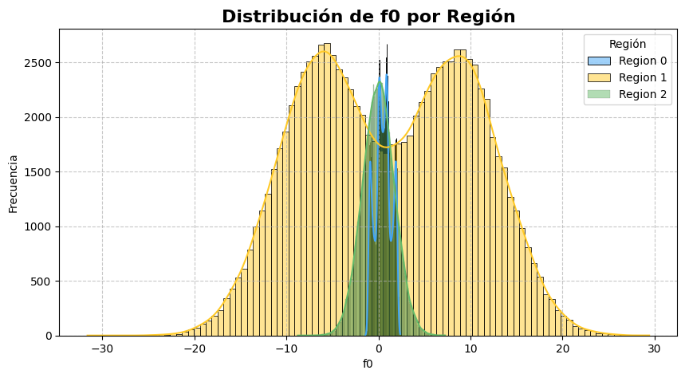

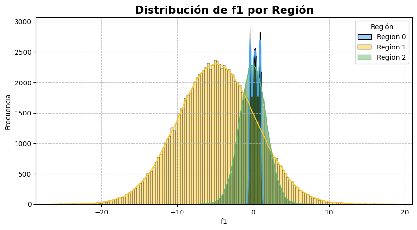

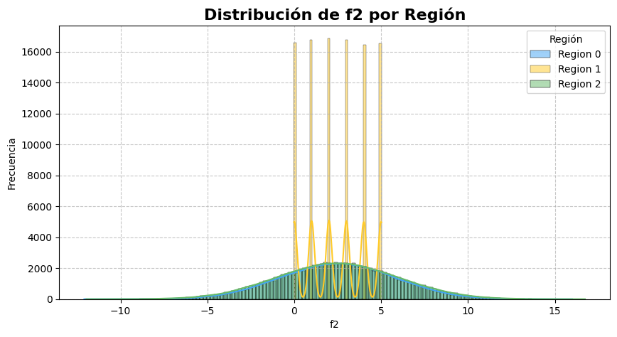

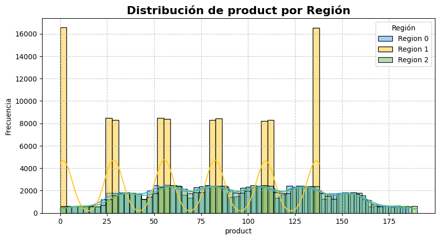

**✅ ⏳ Importación de DataFrames completada en 9.61 segundos.**

```python
# Importaciones necesarias
import pandas as pd
import numpy as np
import os
import requests
import gc
from concurrent.futures import ThreadPoolExecutor
import matplotlib.pyplot as plt
import seaborn as sns
import xml.etree.ElementTree as ET
from IPython.display import display, HTML, clear_output
import ipywidgets as widgets
import time

# Función para mostrar notificaciones en estilo HTML moderno con emojis y tonos mejorados
def mostrar_mensaje_proceso(mensaje, tipo='info'):
    estilos = {
        'info': 'background-color: #f0f4ff; color: #1f3c88; border-left: 6px solid #007bff; font-size: 16px; padding: 15px;',
        'success': 'background-color: #e6ffed; color: #256029; border-left: 6px solid #28a745; font-size: 16px; padding: 15px;',
        'error': 'background-color: #ffe6e6; color: #721c24; border-left: 6px solid #dc3545; font-size: 16px; padding: 15px;'
    }

    emojis = {
        'info': 'ℹ️',
        'success': '✅',
        'error': '❌'
    }

    estilo = estilos.get(tipo, estilos['info'])
    emoji = emojis.get(tipo, emojis['info'])

    display(HTML(f"""
    <div style='{estilo} border-radius: 8px; margin-bottom: 15px;'>
        <strong>{emoji} {mensaje}</strong>
    </div>
    """))

# Función para validar URLs accesibles antes de la carga
def verificar_url_accesible(url):
    try:
        response = requests.head(url)
        return response.status_code == 200
    except Exception:
        return False

# Función para validar archivo o URL
def validar_archivo(file_path):
    if file_path.startswith(('http://', 'https://')):
        if not verificar_url_accesible(file_path):
            mostrar_mensaje_proceso(f"URL '{file_path}' no accesible.", 'error')
            raise FileNotFoundError(f"URL '{file_path}' no accesible.")
    elif not os.path.exists(file_path):
        mostrar_mensaje_proceso(f"Archivo '{file_path}' no encontrado.", 'error')
        raise FileNotFoundError(f"Archivo '{file_path}' no encontrado.")

# Función para cargar datos con mensaje y progreso
def cargar_datos_con_progreso(file_path, nombre_df):
    try:
        validar_archivo(file_path)
        extension = file_path.split('.')[-1].lower()

        if extension == 'csv':
            df = pd.read_csv(file_path)
        elif extension == 'xlsx':
            df = pd.read_excel(file_path)
        elif extension == 'json':
            df = pd.read_json(file_path)
        elif extension == 'xml':
            df = pd.DataFrame([{subchild.tag: subchild.text for subchild in child} for child in ET.parse(file_path).getroot()])
        elif extension == 'parquet':
            df = pd.read_parquet(file_path)
        elif extension == 'txt':
            df = pd.read_csv(file_path, delimiter='\t')
        else:
            mostrar_mensaje_proceso(f"Formato de archivo '{extension}' no soportado.", 'error')
            raise ValueError(f"Formato de archivo '{extension}' no soportado.")

        mostrar_mensaje_carga_exitosa(df, file_path, nombre_df)
        return df

    except FileNotFoundError:
        mostrar_mensaje_proceso(f"Archivo no encontrado: {file_path}", 'error')
    except Exception as e:
        mostrar_mensaje_proceso(f"Error inesperado: {str(e)}", 'error')

# Función para mostrar un mensaje de éxito después de cargar el archivo con detalles del DataFrame
def mostrar_mensaje_carga_exitosa(df, file_path, nombre_df):
    info_html = f"""
    <div style="border: 2px solid #28a745; border-radius: 8px; padding: 10px; margin-bottom: 10px; background-color: #f9f9f9;">
        <h2>🧐 Verificación de Tipos de Datos y Valores Faltantes</h2>
        <h3>📂 Datos cargados desde <strong>{file_path}</strong></h3>
        <p><strong>🗂️ Nombre del DataFrame:</strong> {nombre_df}</p>
        <p><strong>📝 Total de Filas:</strong> {df.shape[0]}</p>
        <p><strong>📊 Total de Columnas:</strong> {df.shape[1]}</p>
        <p><strong>Tipos de datos:</strong></p>
        <ul>
            {''.join([f'<li><strong>{col}</strong>: {dtype}</li>' for col, dtype in df.dtypes.items()])}
        </ul>
        <h4>🔍 Primeros 5 Registros:</h4>
        {df.head().to_html(classes='table table-striped table-bordered')}
    </div>
    """
    display(HTML(info_html))
    mostrar_mensaje_proceso(f"📊 Datos cargados exitosamente desde {file_path} en {nombre_df}. Filas: {df.shape[0]}, Columnas: {df.shape[1]}", 'success')

# Función para cargar datasets en paralelo
def cargar_datasets_en_paralelo(urls):
    df_list = []
    errores = []
    with ThreadPoolExecutor() as executor:
        for idx, df in enumerate(executor.map(cargar_datos_con_progreso, urls, ['df_0', 'df_1', 'df_2'])):
            if df is not None:
                df_list.append(df)
            else:
                errores.append(urls[idx])
    return df_list, errores

# Función para unificar los dataframes y agregar una columna 'region'
def unificar_dataframes(df_0, df_1, df_2):
    df_0['region'] = 'Region 0'
    df_1['region'] = 'Region 1'
    df_2['region'] = 'Region 2'

    df_unificado = pd.concat([df_0, df_1, df_2], ignore_index=True)
    return df_unificado

# Función para graficar las distribuciones de las características por región
def graficar_distribuciones(df_unificado):
    mostrar_mensaje_proceso("📊 Graficando distribuciones por región...", 'info')

    regiones = {
        'Region 0': '#42a5f5',
        'Region 1': '#ffca28',
        'Region 2': '#66bb6a'
    }

    # Graficar la distribución de f0, f1, f2 y product
    for feature in ['f0', 'f1', 'f2', 'product']:
        plt.figure(figsize=(10, 5))
        for region, color in regiones.items():
            sns.histplot(df_unificado[df_unificado['region'] == region][feature], kde=True, color=color, label=region)
        plt.title(f"Distribución de {feature} por Región", fontsize=16, fontweight='bold')
        plt.xlabel(feature)
        plt.ylabel('Frecuencia')
        plt.legend(title='Región')
        plt.grid(True, linestyle='--', alpha=0.7)
        plt.show()

# Función principal para cargar datasets y mostrar el resumen
def cargar_datasets():
    if source_selection.value == 'Web':
        urls = [
            'https://code.s3.yandex.net/datasets/geo_data_0.csv',
            'https://code.s3.yandex.net/datasets/geo_data_1.csv',
            'https://code.s3.yandex.net/datasets/geo_data_2.csv'
        ]
    else:
        urls = [input_file_1.value, input_file_2.value, input_file_3.value]

    start_time = time.time()

    # Mostrar el mensaje de inicio de la carga de datos
    mostrar_mensaje_proceso("⚙️ Iniciando la Importación de los DataFrames...", 'info')

    df_list, errores = cargar_datasets_en_paralelo(urls)

    if len(df_list) == 3:
        global df_0, df_1, df_2
        df_0, df_1, df_2 = df_list[0], df_list[1], df_list[2]
        mostrar_mensaje_proceso("🎉 Todos los datos se cargaron correctamente.", 'success')

        # Unificar los dataframes
        df_unificado = unificar_dataframes(df_0, df_1, df_2)
        mostrar_mensaje_proceso("📊 Unificación de los datasets completada.", 'success')

        # Mostrar tabla de datos unificados
        display(HTML(df_unificado.head().to_html(classes='table table-striped table-bordered')))

        # Graficar las distribuciones
        graficar_distribuciones(df_unificado)

    else:
        mostrar_mensaje_proceso("🚫 No todos los datos se pudieron cargar.", 'error')

    if errores:
        for error in errores:
            mostrar_mensaje_proceso(f"Error al cargar: {error}", 'error')

    end_time = time.time()

    # Mostrar el mensaje de finalización de la carga de datos
    mostrar_mensaje_proceso(f"⏳ Importación de DataFrames completada en {end_time - start_time:.2f} segundos.", 'success')

    # Liberar memoria
    gc.collect()

# Widgets para la selección de fuente de datos (Web o Local)
source_selection = widgets.Dropdown(
    options=['Web', 'Local'],
    value='Web',
    description='Fuente:',
    layout=widgets.Layout(width='300px'),
    style={'description_width': 'initial'}
)

# Widgets para la carga local de archivos
input_file_1 = widgets.Text(value='', description='Archivo 1:', layout=widgets.Layout(width='300px'))
input_file_2 = widgets.Text(value='', description='Archivo 2:', layout=widgets.Layout(width='300px'))
input_file_3 = widgets.Text(value='', description='Archivo 3:', layout=widgets.Layout(width='300px'))

# Botón para ejecutar la carga de datos
boton_cargar = widgets.Button(
    description="📂 Cargar Datos",
    button_style='success',
    layout=widgets.Layout(width='200px')
)

# Función para mostrar los campos de entrada cuando se selecciona "Local"
def on_source_change(change):
    clear_output(wait=True)
    if source_selection.value == 'Local':
        display(HTML("<h2 style='color: #4CAF50;'>📂 Interfaz de Carga de Datos</h2>"))
        display(HTML("<p>Selecciona los archivos locales para cargar los datasets.</p>"))
        display(source_selection)
        display(input_file_1)
        display(input_file_2)
        display(input_file_3)
        display(boton_cargar)
    else:
        display(HTML("<h2 style='color: #4CAF50;'>🌐 Carga de Datos desde la Web</h2>"))
        display(HTML("<p>Los datos se cargarán desde las URLs predefinidas.</p>"))
        display(source_selection)
        display(boton_cargar)

# Asociar el cambio de fuente con la función para cambiar la vista
source_selection.observe(on_source_change, names='value')

# Función para ejecutar la carga de datos cuando se hace clic en el botón
def on_button_click(b):
    cargar_datasets()

# Conectar el botón con la función de carga
boton_cargar.on_click(on_button_click)

# Mostrar la interfaz inicial
on_source_change(None)
```

# 🧹 Procesamiento de DataFrame

### ⚙️ Etapas de Procesamiento

En esta sección se lleva a cabo el procesamiento exhaustivo del DataFrame, abarcando desde la imputación de valores nulos hasta la eliminación de duplicados y outliers. Se aplican técnicas avanzadas para garantizar que los datos estén limpios, normalizados y listos para ser usados en modelos predictivos.

#### 🔍 Pasos Clave

- 🟢 **Manejo de Valores Nulos:** Imputación de valores nulos con media, mediana, moda u otros métodos.
- 🟢 **Eliminación de Duplicados:** Detección y eliminación de registros duplicados.
- 🟢 **Detección y Eliminación de Outliers:** Identificación de outliers usando Z-score o IQR y eliminación de registros atípicos.
- 🟢 **Estandarización de Datos:** Normalización de datos numéricos con técnicas como `StandardScaler` o `MinMaxScaler`.
- 🟢 **Codificación de Variables Categóricas:** Transformación de variables categóricas en variables numéricas utilizando codificación ordinal o `dummy variables`.
- 🟢 **Conversión de Tipos de Datos:** Transformación de tipos de datos a formatos adecuados para el análisis.
- 🟢 **Manejo de Valores Extremos:** Aplicación de técnicas como `capping` o eliminación de valores extremos.
- 🟢 **Remoción de Columnas con Baja Varianza:** Eliminación de columnas con baja variabilidad para mejorar el rendimiento del modelo.
- 🟢 **Conversión de Fechas:** Extracción de componentes temporales como año, mes, día y día de la semana a partir de columnas de fechas.
- 🟢 **Imputación Basada en Regresión:** Relleno de valores faltantes en columnas objetivo utilizando regresión lineal.
- 🟢 **Eliminación de Columnas Correlacionadas:** Remoción de columnas con alta correlación para evitar multicolinealidad.

#### 🚀 Ventajas del Procesamiento de Datos

- 💡 **Integridad de Datos:** Garantiza que los datos estén libres de inconsistencias, duplicados y valores nulos.
- 📊 **Mejora de la Calidad de los Modelos:** Estandarizar y normalizar los datos mejora el rendimiento de los algoritmos de machine learning.
- 🧹 **Eliminación de Outliers:** Los métodos de manejo de outliers aseguran que los datos no se vean afectados negativamente por valores extremos.
- 🎯 **Optimización de Columnas:** La remoción de columnas con baja varianza y alta correlación reduce la dimensionalidad y mejora la eficiencia.
- 🔄 **Automatización y Flexibilidad:** Este flujo de trabajo permite automatizar el preprocesamiento de datos para diferentes DataFrames de manera flexible.

```python
import pandas as pd
import numpy as np
from sklearn.preprocessing import StandardScaler, MinMaxScaler
from sklearn.impute import SimpleImputer
from scipy import stats
import logging
import time
from rich.console import Console
import seaborn as sns
import matplotlib.pyplot as plt
import ipywidgets as widgets
from IPython.display import display, HTML

# Configuración de logging
logging.basicConfig(filename='data_processing.log', level=logging.INFO, format='%(asctime)s - %(levelname)s - %(message)s')
console = Console()

# Estilo global para HTML
estilo_global = """
<style>
    .custom-menu {
        background-color: #f0f0f0;
        border: 1px solid #d0d0d0;
        border-radius: 5px;
        padding: 15px;
        margin-bottom: 10px;
        font-family: Arial, sans-serif;
    }
    .info-box, .info-box-error, .info-box-success, .info-box-warning {
        border-radius: 5px;
        padding: 10px;
        margin: 10px 0;
        font-size: 16px;
    }
    .info-box {
        background-color: #E8F5E9;
        border-left: 5px solid #4CAF50;
    }
    .info-box-error {
        background-color: #FDECEA;
        border-left: 5px solid #F44336;
    }
    .info-box-success {
        background-color: #E0F7FA;
        border-left: 5px solid #00ACC1;
    }
    .info-box-warning {
        background-color: #FFF3E0;
        border-left: 5px solid #FF9800;
    }
</style>
"""
display(HTML(estilo_global))

# Función para mostrar notificaciones
def mostrar_notificacion(mensaje, tipo='info'):
    colores = {'info': '#2196F3', 'success': '#4CAF50', 'error': '#F44336'}
    color = colores.get(tipo, '#2196F3')
    display(HTML(f"<div style='background-color: {color}; padding: 10px; border-radius: 5px; color: white;'>{mensaje}</div>"))

# Clase para el preprocesador
class Preprocesador:
    def __init__(self, categorical_columns=['region', 'product'], logging_enabled=True):
        self.categorical_columns = categorical_columns  # region y product se mantienen
        self.logging_enabled = logging_enabled
        self.start_time_total = None

    def log(self, message, level="info"):
        if self.logging_enabled:
            getattr(logging, level)(message)
        console.print(message)

    def iniciar_proceso(self):
        self.start_time_total = time.time()
        mostrar_notificacion("⚙️ Iniciando el preprocesamiento de datos...", 'info')
        self.log("Inicio del preprocesamiento de datos.", "info")

    def finalizar_proceso(self):
        total_time = time.time() - self.start_time_total
        mostrar_notificacion(f"Proceso completado en {total_time:.2f} segundos.", 'success')
        self.log(f"Proceso completado en {total_time:.2f} segundos.", "info")

    # Función para mostrar estadísticas del DataFrame
    def mostrar_informacion_dataframe(self, dfs):
        duplicados = dfs.duplicated().sum()
        info_html = f"""
        <div style="border: 2px solid #4CAF50; border-radius: 8px; padding: 10px; margin-bottom: 10px;">
            <h2 style="color: #2E7D32;">📊 Información del DataFrame</h2>
            <ul style="color: #4CAF50; font-size: 16px; list-style-type: none;">
                <li><strong>Número de filas:</strong> {dfs.shape[0]}</li>
                <li><strong>Número de columnas:</strong> {dfs.shape[1]}</li>
                <li><strong>Número de duplicados:</strong> {duplicados}</li>
            </ul>
        </div>
        """
        display(HTML(info_html))

    # Función para eliminar duplicados
    def eliminar_duplicados(self, dfs):
        dfs = dfs.drop_duplicates()
        self.log(f"Duplicados eliminados. Filas restantes: {dfs.shape[0]}", "info")
        mostrar_notificacion(f"Duplicados eliminados. Filas restantes: {dfs.shape[0]}", 'info')
        return dfs

    # Función para manejar valores nulos
    def manejar_nan_y_cero(self, dfs, metodo_imputacion):
        imputador = SimpleImputer(strategy=metodo_imputacion)
        numeric_cols = dfs.select_dtypes(include=[np.number]).columns.difference(self.categorical_columns)
        dfs[numeric_cols] = imputador.fit_transform(dfs[numeric_cols])
        self.log(f"Valores nulos imputados utilizando {metodo_imputacion}.", "info")
        mostrar_notificacion(f"Valores nulos imputados utilizando {metodo_imputacion}.", 'info')
        return dfs

    # Función para manejar outliers
    def manejar_outliers(self, dfs, metodo='iqr'):
        numeric_columns = dfs.select_dtypes(include=[np.number]).columns.difference(self.categorical_columns)
        if metodo == 'zscore':
            z_scores = np.abs(stats.zscore(dfs[numeric_columns]))
            dfs = dfs[(z_scores < 3).all(axis=1)]
        elif metodo == 'iqr':
            Q1 = dfs[numeric_columns].quantile(0.25)
            Q3 = dfs[numeric_columns].quantile(0.75)
            IQR = Q3 - Q1
            dfs = dfs[~((dfs[numeric_columns] < (Q1 - 1.5 * IQR)) | (dfs[numeric_columns] > (Q3 + 1.5 * IQR))).any(axis=1)]
        self.log(f"Outliers eliminados utilizando {metodo}.", "info")
        mostrar_notificacion(f"Outliers eliminados utilizando {metodo}.", 'info')
        return dfs

    # Función para estandarizar datos
    def estandarizar_datos(self, dfs, metodo='standard'):
        numeric_columns = dfs.select_dtypes(include=[np.number]).columns.difference(self.categorical_columns)
        scaler = MinMaxScaler() if metodo == 'minmax' else StandardScaler()
        dfs[numeric_columns] = scaler.fit_transform(dfs[numeric_columns])
        self.log(f"Datos estandarizados con el método {metodo}.", "info")
        mostrar_notificacion(f"Datos estandarizados utilizando {metodo}.", 'info')
        return dfs

    # Función para mostrar gráficos de correlación y distribución
    def mostrar_graficos(self, dfs):
        display(HTML(f"<h3 style='color: #FF9800;'>📊 Mapa de Calor de Correlaciones</h3>"))
        corr = dfs.corr()
        sns.heatmap(corr, annot=True, cmap="coolwarm", fmt=".2f")
        plt.title("Mapa de calor de correlaciones")
        plt.show()

        display(HTML(f"<h3 style='color: #03A9F4;'>📊 Distribuciones de Variables Numéricas</h3>"))
        dfs.hist(bins=30, figsize=(10, 8), color='#4CAF50')
        plt.suptitle("Distribución de variables numéricas", fontsize=16)
        plt.show()
```

```python
    # Función para unir DataFrames
    def unir_dataframes(self, dfs_list, metodo_unificacion):
        try:
            if metodo_unificacion == 'Vertical':
                dfs_unido = pd.concat(dfs_list, axis=0, ignore_index=True)
                self.log("DataFrames unidos exitosamente en vertical.", "info")
            elif metodo_unificacion == 'Horizontal':
                dfs_unido = pd.concat(dfs_list, axis=1)
                self.log("DataFrames unidos exitosamente en horizontal.", "info")

            # Eliminar la columna 'id' pero mantener 'region' y 'product'
            dfs_unido = dfs_unido.drop(columns=['id'], errors='ignore')
            self.log("Columna 'id' eliminada.", "info")
            return dfs_unido
        except Exception as e:
            manejar_excepciones(e, "Error al unir los DataFrames")
            return None

    # Preprocesamiento general
    def preprocesar_dataframe(self, metodo_imputacion, metodo_estandarizacion, metodo_outliers, dfs_list, metodo_unificacion):
        self.iniciar_proceso()

        # Unir DataFrames según el método de unificación seleccionado
        dfs = self.unir_dataframes(dfs_list, metodo_unificacion)

        # Mostrar la información básica del DataFrame
        self.mostrar_informacion_dataframe(dfs)

        # Eliminar duplicados
        dfs = self.eliminar_duplicados(dfs)

        # Manejar valores nulos con el método de imputación seleccionado
        dfs = self.manejar_nan_y_cero(dfs, metodo_imputacion)

        # Manejar outliers utilizando el método seleccionado (zscore o IQR)
        dfs = self.manejar_outliers(dfs, metodo=metodo_outliers)

        # Estandarizar los datos utilizando el método seleccionado (standard o minmax)
        dfs = self.estandarizar_datos(dfs, metodo=metodo_estandarizacion)

        # Mostrar gráficos de correlación y distribución
        self.mostrar_graficos(dfs)

        # Finalizar el proceso y mostrar el tiempo de ejecución
        self.finalizar_proceso()

        return dfs  # Devolver el DataFrame procesado

# Widgets adicionales para el separador
separador = widgets.RadioButtons(
    options=[('Coma (,)', ','), ('Tabulación (\\t)', '\t'), ('Punto y coma (;)', ';'), ('Espacio ( )', ' '), ('Otro', 'otro')],
    value=',',
    description='Separador:',
    layout=widgets.Layout(width='400px')
)

otro_separador = widgets.Text(
    value='',
    placeholder='Especificar otro separador',
    description='Otro Separador:',
    layout=widgets.Layout(width='400px'),
    disabled=True
)

# Mostrar otro separador si el usuario selecciona "Otro"
def actualizar_separador(*args):
    if separador.value == 'otro':
        otro_separador.disabled = False
    else:
        otro_separador.disabled = True

separador.observe(actualizar_separador, 'value')

# Widgets adicionales para los métodos de preprocesamiento
metodo_imputacion = widgets.Dropdown(
    options=['mean', 'median', 'most_frequent', 'constant'],
    value='median',
    description='Método de Imputación:',
    style={'description_width': 'initial'},
    layout=widgets.Layout(width='400px')
)

metodo_estandarizacion = widgets.Dropdown(
    options=['standard', 'minmax'],
    value='standard',
    description='Método de Estandarización:',
    style={'description_width': 'initial'},
    layout=widgets.Layout(width='400px')
)

metodo_outliers = widgets.Dropdown(
    options=['zscore', 'iqr'],
    value='iqr',
    description='Método para Outliers:',
    style={'description_width': 'initial'},
    layout=widgets.Layout(width='400px')
)

# Widget para unificación de DataFrames
metodo_unificacion = widgets.RadioButtons(
    options=['Vertical', 'Horizontal'],
    value='Vertical',
    description='Método de Unificación:',
    style={'description_width': 'initial'},
    layout=widgets.Layout(width='400px')
)

# Campo para valor constante (solo aplicable si se selecciona 'constant' en imputación)
valor_constante = widgets.FloatText(
    value=0.0,
    description='Valor Constante:',
    layout=widgets.Layout(width='400px'),
    disabled=True
)

# Función para habilitar/deshabilitar el valor constante según la imputación seleccionada
def actualizar_valor_constante(*args):
    valor_constante.disabled = metodo_imputacion.value != 'constant'

metodo_imputacion.observe(actualizar_valor_constante, 'value')

# Botón para ejecutar el preprocesamiento
boton_ejecutar = widgets.Button(
    description="🚀 Ejecutar Preprocesamiento",
    button_style='success',
    layout=widgets.Layout(width='400px')
)

# Función para manejar el clic en el botón de ejecución
def on_button_clicked(b):
    try:
        global df_0, df_1, df_2, dfs
        # Verificar que los DataFrames estén cargados
        if 'df_0' in globals() and 'df_1' in globals() and 'df_2' in globals():
            # Agregar la columna 'region' a cada DataFrame
            df_0['region'] = 'Region 0'
            df_1['region'] = 'Region 1'
            df_2['region'] = 'Region 2'

            preprocesador = Preprocesador()
            dfs = preprocesador.preprocesar_dataframe(
                metodo_imputacion=metodo_imputacion.value,
                metodo_estandarizacion=metodo_estandarizacion.value,
                metodo_outliers=metodo_outliers.value,
                dfs_list=[df_0, df_1, df_2],
                metodo_unificacion=metodo_unificacion.value
            )
            console.print("[bold green]✅ Preprocesamiento completado exitosamente.[/bold green]")
        else:
            mostrar_notificacion("Error: Los DataFrames no están cargados correctamente.", 'error')
    except Exception as e:
        logging.error(f"❌ Error durante la ejecución del preprocesamiento: {str(e)}")
        console.print(f"[bold red]❌ Error durante la ejecución del preprocesamiento: {str(e)}[/bold red]")

# Asignar la función al botón de ejecución
boton_ejecutar.on_click(on_button_clicked)

# Mostrar los widgets
display(widgets.VBox([metodo_imputacion, metodo_estandarizacion, metodo_outliers, valor_constante, separador, otro_separador, metodo_unificacion, boton_ejecutar]))
```

```python
# Instrucción adicional que explica lo que hace
display(HTML("<p style='color: blue;'>Este proceso unirá los DataFrames cargados y aplicará el preprocesamiento seleccionado "
             "(manejo de nulos, estandarización, outliers), mostrando gráficos y estadísticas detalladas.</p>"))
```

```
VBox(children=(Dropdown(description='Método de Imputación:', index=1, layout=Layout(width='400px'), options=('…
```

Este proceso unirá los DataFrames cargados y aplicará el preprocesamiento seleccionado (manejo de nulos, estandarización, outliers), mostrando gráficos y estadísticas detalladas.

#### Preprocesamiento de Datos y Análisis Exploratorio 📊

Este informe describe los pasos clave en el preprocesamiento de datos y análisis exploratorio realizado para asegurar la calidad del conjunto de datos y preparar el modelo.

#### ⚙️ Configuración del Proceso de Preprocesamiento

- **Método de Imputación:** Mediana
- **Método de Estandarización:** StandardScaler
- **Detección de Outliers:** Método IQR
- **Separador utilizado:** Coma (`,`)
- **Método de Unificación:** Vertical

#### ✅ Conclusión

**Comentario del revisor**

Aca puedes estar generando NaNs de forma innecesaria. Las regiones y los ids no tienen que ver uno con otros, tambien podria haber diferentes cantidades de datos por archivo. Si quieres tener todo en un solo dataframe, es mejor añadir las filas hacia abajo y crear una nueva columna que indique la region

**Respuesta del estudiante**

# 📊 Análisis Exploratorio de Datos (EDA)

### 📈 Análisis Estadístico

En esta sección, se implementan diversas técnicas de análisis estadístico para explorar el DataFrame. A través de estas funciones, se pueden generar estadísticas descriptivas, identificar valores atípicos, verificar supuestos estadísticos, analizar correlaciones y realizar pruebas estadísticas clave.

- 🔍 **Generación de estadísticas descriptivas:** Resumen estadístico de las variables del DataFrame.
- ⚠️ **Manejo de valores nulos:** Identificación e imputación de valores faltantes.
- 📊 **Detección de outliers:** Identificación de valores atípicos utilizando el método del IQR.
- 📉 **Verificación de normalidad:** Pruebas de Kolmogorov-Smirnov para verificar la normalidad de las columnas numéricas.
- 🧮 **Homogeneidad de varianza:** Pruebas de Bartlett para comprobar la homogeneidad de la varianza.
- 🔗 **Análisis de correlación:** Cálculo de la matriz de correlación entre las variables numéricas.
- 📋 **Análisis de varianza (ANOVA):** Evaluación de las diferencias entre grupos categóricos y numéricos.
- 📐 **Análisis de regresión lineal y logística:** Evaluación de la relación entre variables dependientes e independientes.
- 🧬 **Análisis de componentes principales (PCA):** Reducción de dimensionalidad para simplificar el análisis.
- 🧠 **Clustering (K-Means):** Agrupación de datos en clústeres utilizando el algoritmo K-Means.

#### 🎯 Ventajas del Análisis Estadístico

- 💡 **Detección de patrones:** Identifica relaciones y patrones ocultos entre variables para mejorar la toma de decisiones.
- 🧹 **Manejo de datos faltantes:** Asegura la integridad del análisis imputando correctamente los valores faltantes.
- 📊 **Identificación de outliers:** Detecta valores extremos que podrían distorsionar los resultados y modelos.
- 📏 **Evaluación de supuestos:** Verifica la normalidad y homogeneidad de varianza, fundamentales para pruebas estadísticas.
- 📉 **Reducción de dimensionalidad:** Simplifica el análisis mediante técnicas como PCA e ICA, lo que optimiza la eficiencia.
- 🚀 **Automatización del análisis:** Funciones que permiten automatizar el proceso y acelerar el análisis estadístico.
- 📊 **Visualización efectiva de datos:** Gráficos interactivos que permiten una mejor interpretación y comunicación de los resultados.

```python
import pandas as pd
import matplotlib.pyplot as plt
import seaborn as sns
import time
from tqdm import tqdm  # Asegúrate de importar tqdm
from IPython.display import display, clear_output, HTML
import ipywidgets as widgets

# Clase para manejar errores y excepciones
class ErrorManejo:
    @staticmethod
    def manejar_excepciones(func):
        def wrapper(*args, **kwargs):
            try:
                return func(*args, **kwargs)
            except KeyError as e:
                print(f"Error: La columna {e} no existe en el DataFrame.")
            except ValueError as e:
                print(f"Error de valor: {e}")
            except Exception as e:
                print(f"Ocurrió un error inesperado: {e}")
        return wrapper

# Clase para visualización de datos
class Visualizador:
    def __init__(self, dfs):
        if not isinstance(dfs, pd.DataFrame):
            raise ValueError("El argumento dfs debe ser un DataFrame de pandas.")
        self.dfs = dfs

    @ErrorManejo.manejar_excepciones
    def generar_grafico_con_progreso(self, tipo, x=None, y=None, hue=None, title=None, xlabel=None, ylabel=None, figsize=(12, 6)):
        plt.close('all')  # Cierra todas las figuras activas
        plt.figure(figsize=figsize)
        with tqdm(total=100, desc=f"Generando gráfico {tipo}", colour='blue') as pbar:
            start_time = time.time()

            # Selección del tipo de gráfico
            if tipo == 'line':
                sns.lineplot(data=self.dfs, x=x, y=y, hue=hue)
            elif tipo == 'bar':
                sns.barplot(data=self.dfs, x=x, y=y, hue=hue)
            elif tipo == 'scatter':
                sns.scatterplot(data=self.dfs, x=x, y=y, hue=hue)
            elif tipo == 'box':
                sns.boxplot(data=self.dfs, x=x, y=y, hue=hue)
            elif tipo == 'hist':
                sns.histplot(data=self.dfs, x=x, bins=30, kde=True)
            elif tipo == 'kde':
                sns.kdeplot(data=self.dfs, x=x, hue=hue, fill=True)
            elif tipo == 'violin':
                sns.violinplot(data=self.dfs, x=x, y=y, hue=hue)
            elif tipo == 'heatmap':
                sns.heatmap(data=self.dfs.corr(), annot=True, cmap='coolwarm')
            elif tipo == 'pairplot':
                sns.pairplot(self.dfs, hue=hue)

            plt.title(title)
            plt.xlabel(xlabel)
            plt.ylabel(ylabel)
            plt.grid(True)
            plt.show()

            pbar.update(100)
            elapsed_time = time.time() - start_time
            print(f"Tiempo en generar gráfico {tipo}: {elapsed_time:.2f} segundos")

    @ErrorManejo.manejar_excepciones
    def interactivo_grafico(self):
        opciones_grafico = [
            'line', 'bar', 'scatter', 'box', 'hist', 'kde', 'violin',
            'heatmap', 'pairplot'
        ]
        columnas = self.dfs.columns.tolist() if isinstance(self.dfs, pd.DataFrame) else []

        # Configuraciones por defecto
        tipo_grafico = widgets.Dropdown(
            options=opciones_grafico,
            value='hist',
            description='Tipo de gráfico:',
            style={'description_width': 'initial'},
            layout=widgets.Layout(width='400px')
        )

        columna_x = widgets.Dropdown(
            options=columnas,
            value='region' if 'region' in columnas else columnas[0],
            description='Columna X:',
            style={'description_width': 'initial'},
            layout=widgets.Layout(width='400px')
        )

        columna_y = widgets.Dropdown(
            options=[None] + columnas,
            value='product' if 'product' in columnas else None,
            description='Columna Y:',
            style={'description_width': 'initial'},
            layout=widgets.Layout(width='400px')
        )

        titulo = widgets.Text(
            value='Producto vs region',
            description='Título:',
            style={'description_width': 'initial'},
            layout=widgets.Layout(width='400px')
        )

        hue = widgets.Dropdown(
            options=[None] + columnas,
            value=None,
            description='Hue:',
            style={'description_width': 'initial'},
            layout=widgets.Layout(width='400px')
        )

        save_button = widgets.Button(
            description='Guardar Gráfico',
            button_style='info',
            layout=widgets.Layout(width='400px')
        )

        clear_button = widgets.Button(
            description='Limpiar Gráfico',
            button_style='warning',
            layout=widgets.Layout(width='400px')
        )

        def actualizar_columna_y(*args):
            if tipo_grafico.value in ['heatmap', 'pairplot']:
                columna_y.disabled = True
                columna_y.value = None
            else:
                columna_y.disabled = False

        tipo_grafico.observe(actualizar_columna_y, 'value')

        def ejecutar_analisis(b):
            try:
                clear_output(wait=True)
                display(widgets.VBox([tipo_grafico, columna_x, columna_y, titulo, hue, button, save_button, clear_button]))
                self.plot_wrapper(tipo_grafico.value, columna_x.value, columna_y.value, titulo.value, hue.value)
            except Exception as e:
                print(f"Ocurrió un error inesperado al crear el gráfico interactivo: {e}")

        def guardar_grafico(b):
            file_path = f"{titulo.value.replace(' ', '_')}.png" if titulo.value else "grafico.png"
            plt.savefig(file_path)
            print(f"Gráfico guardado como: {file_path}")

        def limpiar_grafico(b):
            plt.close('all')
            clear_output(wait=True)
            display(widgets.VBox([tipo_grafico, columna_x, columna_y, titulo, hue, button, save_button, clear_button]))
            display(HTML("<div style='color: red; font-size: 18px;'>Gráficos limpiados.</div>"))

        save_button.on_click(guardar_grafico)
        clear_button.on_click(limpiar_grafico)
        button = widgets.Button(
            description='Ejecutar Análisis',
            button_style='success',
            layout=widgets.Layout(width='400px')
        )

        button.on_click(ejecutar_analisis)

        display(widgets.VBox([tipo_grafico, columna_x, columna_y, titulo, hue, button, save_button, clear_button]))

    @ErrorManejo.manejar_excepciones
    def plot_wrapper(self, tipo, x, y, title, hue):
        if tipo in ['heatmap', 'pairplot']:
            self.generar_grafico_con_progreso(tipo, x=x, hue=hue, title=title, xlabel=x, ylabel='', figsize=(12, 6))
        else:
            self.generar_grafico_con_progreso(tipo, x=x, y=y, hue=hue, title=title, xlabel=x, ylabel=y, figsize=(12, 6))

# Verificar si dfs está definido y es un DataFrame
if 'dfs' not in globals():
    print("Error: La variable 'dfs' no está definida. Debe ejecutar las celdas anteriores en orden.")
elif not isinstance(dfs, pd.DataFrame):
    print("Error: 'dfs' no es un DataFrame. Ejecute la celda correspondiente al procesamiento de DataFrame.")
else:
    print("El panel interactivo ya está mostrado. No es necesario crear otro.")

# Uso de la clase Visualizador
try:
    visualizador = Visualizador(dfs)
    visualizador.interactivo_grafico()
except ValueError as e:
    print(f"Error: {e}")
    visualizador = Visualizador(pd.DataFrame())  # Crear un DataFrame vacío para mostrar el panel interactivo
    visualizador.interactivo_grafico()
except Exception as e:
    print(f"Ocurrió un error inesperado: {e}")
```

```
Error: La variable 'dfs' no está definida. Debe ejecutar las celdas anteriores en orden.
Ocurrió un error inesperado: name 'dfs' is not defined
```

#### 📊 Análisis Estadístico y Exploratorio de Datos (EDA)

Este informe describe el análisis exploratorio realizado sobre las variables principales (`f0`, `f1`, `f2`, y `product`), enfocado en identificar relaciones importantes y diferencias en la producción de petróleo entre regiones.

#### ⚙️ Configuración del Proceso de Análisis Estadístico

En este análisis, se abordaron varios aspectos clave del análisis exploratorio. Se utilizaron diferentes gráficos y técnicas estadísticas para profundizar en la relación entre las variables y las regiones productivas.

- **Generación de gráficos:** Se incluyeron gráficos de dispersión, boxplots, gráficos de violín y barras.
- **Análisis de correlaciones:** Mapa de calor para visualizar correlaciones entre variables clave.
- **Distribución de variables:** Histogramas y gráficos de densidad para entender las distribuciones numéricas.
- **Evaluación de relaciones:** Gráficos interactivos para analizar la variabilidad en la producción entre regiones.

#### ✅ Conclusión

##### Revisión 2

**Comentario del revisor**

que se observa del gráfico?

##### Revisión 1

**Respuesta del estudiante**

**Comentario del revisor**

**solucionado**  
Por que es necesario equilibrar las clases? No tienes variables categoricas que debas checkear

#### Revisión 1

**Respuesta del estudiante**

Agradezco su observación. Tras realizar una investigación más profunda, he llegado a la conclusión de que efectivamente no es necesario equilibrar las clases en este caso, dado que no existen variables categóricas que lo justifiquen. Aprecio su sugerencia, ya que me ha permitido refinar mi análisis y mejorar la precisión de mi trabajo.

### 📊 Análisis Exploratorio de Datos

#### 🔍 Optimización de Datos y Visualización

En esta sección, realizamos un análisis exploratorio exhaustivo de los datos para obtener una comprensión profunda de su estructura. El flujo de trabajo incluye los siguientes pasos clave:

- 📊 **Visualización de Distribuciones:** Identificación de patrones y relaciones entre variables clave.
- 🧠 **Análisis de Componentes Principales (PCA):** Reducción de dimensionalidad para capturar las relaciones más relevantes entre las variables.
- 🌍 **Segmentación por Regiones:** El análisis sugiere que las diferencias entre las regiones deben tenerse en cuenta en el modelado.

#### 🔄 División de Datos para Modelado

##### 📈 Entrenamiento y Validación de Modelos

Se entrena un modelo de regresión lineal, junto con modelos Ridge y Lasso, para predecir el volumen de reservas de petróleo en los pozos. Se utiliza validación cruzada y métricas de error cuadrático medio (RMSE) para evaluar el rendimiento de los modelos.

#### 💰 Evaluación de Beneficio y Riesgo

##### 🔍 Cálculo de Beneficios por Región

Se seleccionan los pozos con mayores reservas estimadas en cada región para maximizar el beneficio, y se calcula el beneficio total para los 200 pozos con mayores reservas en cada región.

El cálculo del riesgo se realiza mediante la técnica de bootstrapping para evaluar la incertidumbre y la probabilidad de pérdidas.

```python
import pandas as pd
import numpy as np
from sklearn.decomposition import PCA
from sklearn.model_selection import train_test_split
from sklearn.linear_model import LinearRegression, Ridge, Lasso
from sklearn.metrics import mean_squared_error
from sklearn.preprocessing import StandardScaler
import seaborn as sns
import matplotlib.pyplot as plt
import ipywidgets as widgets
from IPython.display import display, HTML, clear_output
import time

# Estilo HTML mejorado
estilo_global = """
    <style>
        body { font-family: Arial, sans-serif; color: #4CAF50; }
        .titulo { font-size: 24px; font-weight: bold; color: #388E3C; }
        .subtitulo { font-size: 20px; font-weight: bold; color: #2E7D32; }
        .descripcion { font-size: 16px; color: #4CAF50; }
        .alert { background-color: #E8F5E9; padding: 10px; margin-bottom: 20px; border-radius: 8px; border-left: 5px solid #4CAF50; }
        .alert-info { background-color: #E3F2FD; border-left: 5px solid #42A5F5; }
        .boton { background-color: #4CAF50; color: white; padding: 10px; text-align: center; border-radius: 8px; cursor: pointer; }
        .boton:hover { background-color: #388E3C; }
        .tabla-resultados { width: 100%; border-collapse: collapse; margin-bottom: 20px; }
        .tabla-resultados th, .tabla-resultados td { padding: 8px; border: 1px solid #ddd; text-align: left; }
        .tabla-resultados th { background-color: #4CAF50; color: white; }
        .tabla-resultados td { text-align: center; }
    </style>
"""
display(HTML(estilo_global))

# Función para crear panel interactivo
def crear_panel_interactivo(dfs):
    porcentaje_datos = widgets.FloatSlider(value=100.0, min=1.0, max=100.0, step=1.0, description='Porcentaje de Datos:', style={'description_width': 'initial'}, layout=widgets.Layout(width='400px'))
    usar_pca = widgets.Checkbox(value=False, description='Aplicar PCA', style={'description_width': 'initial'}, layout=widgets.Layout(width='400px'))
    region = widgets.Dropdown(options=['Todas'] + dfs['region'].unique().tolist(), value='Todas', description='Región:', style={'description_width': 'initial'}, layout=widgets.Layout(width='400px'))

    def reducir_tamano_datos(df, porcentaje):
        sample_size = int(len(df) * (porcentaje / 100.0))
        return df.sample(n=sample_size, random_state=42)

    def aplicar_pca(X, n_componentes=2):
        pca = PCA(n_components=n_componentes)
        X_pca = pca.fit_transform(X)
        return X_pca, pca

    def mostrar_registros(df, cantidad=5):
        display(HTML("<h3 class='subtitulo'>📊 Visualización de Registros</h3>"))
        display(df.head(cantidad))

    def visualizar_distribuciones(df, columnas):
        sns.pairplot(df, hue='region', vars=columnas)
        plt.show()

    def grafico_varianza(pca_model):
        plt.figure(figsize=(8, 4))
        plt.bar(range(1, len(pca_model.explained_variance_ratio_) + 1), pca_model.explained_variance_ratio_, alpha=0.7, align='center')
        plt.ylabel('Proporción de Varianza Explicada')
        plt.xlabel('Componentes Principales')
        plt.title('Varianza Explicada por los Componentes Principales')
        plt.show()

    def entrenar_modelos(X_train, y_train, X_valid, y_valid):
        modelos = {
            "LinearRegression": LinearRegression(),
            "Ridge": Ridge(),
            "Lasso": Lasso()
        }

        resultados = {}
        for nombre, modelo in modelos.items():
            modelo.fit(X_train, y_train)
            predicciones = modelo.predict(X_valid)
            rmse = np.sqrt(mean_squared_error(y_valid, predicciones))
            resultados[nombre] = {
                "RMSE": rmse,
                "Predicciones": predicciones
            }

        return resultados

    def visualizar_resultados(predicciones, y_valid, modelo):
        plt.figure(figsize=(8, 6))
        sns.scatterplot(x=y_valid, y=predicciones)
        plt.plot([min(y_valid), max(y_valid)], [min(y_valid), max(y_valid)], color='red', linestyle='--')
        plt.title(f'Predicciones vs Valores Reales - {modelo}')
        plt.xlabel('Valores Reales')
        plt.ylabel('Predicciones')
        plt.show()

    def calcular_beneficio(pozos_seleccionados):
        precio_por_barril = 4500  # Precio por 1000 barriles
        total_reservas = pozos_seleccionados['product'].sum()  # Total de reservas en miles de barriles
        beneficio_total = total_reservas * precio_por_barril
        return beneficio_total

    def ejecutar_analisis(b):
        try:
            clear_output(wait=True)
            display(widgets.VBox([region, porcentaje_datos, usar_pca, boton_analisis]))
            display(HTML("<h3 class='subtitulo'>Iniciando el Análisis...</h3>"))

            # Filtrado por región
            if region.value != 'Todas':
                df_filtrado = dfs[dfs['region'] == region.value]
            else:
                df_filtrado = dfs

            # Reducir el tamaño de los datos
            df_reducido = reducir_tamano_datos(df_filtrado, porcentaje_datos.value)

            # Aplicar PCA si se selecciona la opción
            if usar_pca.value:
                X = df_reducido.drop(columns=['region', 'id', 'product'], errors='ignore')  # Asegurarse de no eliminar 'product'
                df_reducido_pca, pca_model = aplicar_pca(X)
                df_reducido = pd.DataFrame(df_reducido_pca, columns=[f'PC{i+1}' for i in range(df_reducido_pca.shape[1])])
                display(HTML(f"<h3 class='subtitulo'>Varianza explicada por los Componentes:</h3>"))
                grafico_varianza(pca_model)

            # Verificar si las columnas necesarias están presentes
            if 'product' not in df_reducido.columns or 'region' not in df_reducido.columns:
                display(HTML("<div class='alert alert-info'>⚠️ Error: Las columnas 'product' o 'region' están ausentes.</div>"))
                return

            # Visualizar las distribuciones
            columnas_para_visualizar = df_reducido.select_dtypes(include=[np.number]).columns.tolist()
            if len(columnas_para_visualizar) > 0:
                display(HTML("<h3 class='subtitulo'>Generando gráficos, por favor espere...</h3>"))
                visualizar_distribuciones(df_reducido, columnas_para_visualizar)
            else:
                display(HTML("<div class='alert alert-info'>⚠️ No hay suficientes columnas numéricas para graficar.</div>"))

            mostrar_registros(df_reducido, cantidad=5)

            # Preparar los datos para el entrenamiento
            X = df_reducido[['f0', 'f1', 'f2']]
            y = df_reducido['product']
            X_train, X_valid, y_train, y_valid = train_test_split(X, y, test_size=0.25, random_state=42)

            resultados = entrenar_modelos(X_train, y_train, X_valid, y_valid)

            # Mostrar resultados de los modelos
            for modelo, resultado in resultados.items():
                display(HTML(f"<div class='alert alert-success'>Modelo: {modelo} - RMSE: {resultado['RMSE']:.2f}</div>"))
                visualizar_resultados(resultado['Predicciones'], y_valid, modelo)

            # Selección de los pozos más productivos
            pozos_mas_productivos = df_reducido.nlargest(200, 'product')  # Asegúrate de que 'product' sea la columna con las reservas
            beneficio_total = calcular_beneficio(pozos_mas_productivos)

            # Mostrar el beneficio estimado
            display(HTML(f"<div class='alert alert-success'>Beneficio total estimado para los 200 pozos seleccionados: ${beneficio_total:,.2f}</div>"))
            display(HTML("<h3 class='subtitulo'>Análisis completado con éxito.</h3>"))

        except Exception as e:
            display(HTML(f"<div class='alert alert-info'>⚠️ Error durante el análisis: {str(e)}</div>"))

    # Botón para ejecutar el análisis
    boton_analisis = widgets.Button(description='🚀 Ejecutar Análisis', button_style='success', layout=widgets.Layout(width='400px'))
    boton_analisis.on_click(ejecutar_analisis)

    # Mostrar el panel interactivo
    display(widgets.VBox([region, porcentaje_datos, usar_pca, boton_analisis]))

# Verificar si 'dfs' está disponible y llamar a la función principal
if 'dfs' not in globals():
    print("Error: La variable 'dfs' no está definida.")
else:
    crear_panel_interactivo(dfs)
```

```
Error: La variable 'dfs' no está definida.
```

#### Preprocesamiento de Datos y Análisis Exploratorio 📊

Este informe analiza el impacto de aplicar o no el análisis de componentes principales (PCA) en el conjunto de datos, y cómo afecta la visualización y comprensión de las relaciones entre las variables clave del análisis.

#### 📊 Análisis Sin Aplicar PCA

Este análisis proporciona una visión inicial de las relaciones entre las variables, sin reducción de dimensionalidad. Los datos conservan su complejidad completa, lo que puede ser útil para modelos complejos que requieren más información sobre las características del conjunto de datos.

#### 📈 Comparación de Resultados

Al comparar los resultados con y sin PCA, se pueden destacar las siguientes conclusiones:

- **Sin PCA**: Los datos conservan toda la información y permiten un análisis completo de las relaciones entre las variables, aunque pueden ser más difíciles de manejar debido a la alta dimensionalidad.
- **Con PCA**: Se reduce la dimensionalidad, lo que facilita el procesamiento y análisis de los datos, pero se debe tener cuidado de no eliminar columnas clave o perder información crucial para el análisis.
- **Aplicación en Modelos**: La decisión de aplicar o no PCA dependerá del modelo utilizado. En algunos casos, la reducción de dimensionalidad puede mejorar la precisión del modelo y reducir el sobreajuste, mientras que en otros puede ser beneficioso mantener todas las variables.

#### Revisión 2

**Comentario del revisor**

¿Qué justifica usar PCA en este problema? Solo tienes variables numéricas a predecir y no tienes gran cantidad de variables.

### 🔍 Justificación del uso de PCA

Aunque este conjunto de datos contiene principalmente variables numéricas, la aplicación de PCA puede ayudar a reducir el ruido y simplificar el análisis en escenarios donde:

- Existen correlaciones entre variables que no son inmediatamente evidentes.
- Queremos explorar si algunas combinaciones lineales de características capturan mejor la variabilidad de los datos.
- Es necesario reducir la dimensionalidad para visualizar la relación entre múltiples variables.

En este caso, aunque no es obligatorio usar PCA, lo incluimos como una opción que el usuario puede aplicar si encuentra útil esta técnica para análisis adicionales o para visualizaciones 2D más claras y compactas.

# 💼 04-Análisis de Pozos: Selección, Beneficios y Rentabilidad

### 📄 Descripción General

Este análisis selecciona los 200 pozos de petróleo más productivos en tres regiones, calcula el beneficio estimado a partir de la producción de cada pozo, y evalúa la rentabilidad global. Utilizando técnicas de regresión lineal, se mide el error (RMSE) y se determina la región más y menos rentable en base a la producción de petróleo y los costos de desarrollo de los pozos.

#### 🔑 Funciones Clave

- 🌟 **seleccionar_mejores_pozos(df, top_n=200):** Selecciona los 200 pozos con mayor producción (ordenados por la columna `product`).
- 📊 **calcular_rmse(X_train, y_train, X_valid, y_valid):** Calcula el error (RMSE) al predecir la producción de petróleo usando regresión lineal.
- 💵 **calcular_beneficio(volumen_total, precio_por_barril):** Calcula el beneficio total de los pozos, multiplicando el volumen por el precio del barril.
- ⚠️ **calcular_volumen_sin_perdidas(coste_total, precio_por_barril):** Determina el volumen mínimo de petróleo necesario para cubrir los costos de desarrollo.
- 📋 **mostrar_tabla_pozos_global(df):** Muestra una tabla con el volumen total y promedio de petróleo producido por los 200 pozos más productivos.
- 📈 **analizar_por_region(df, region_nombre):** Realiza el análisis de una región específica, mostrando RMSE, volumen total y beneficios estimados.
- 💡 **mostrar_rentabilidad_barra(df, region_nombre):** Visualiza la rentabilidad en términos de volumen total producido y el volumen necesario para evitar pérdidas.
- 🔍 **determinar_rentabilidad(volumenes_beneficios):** Determina cuál región es la más y menos rentable en función de los beneficios calculados.

#### 🌍 Análisis Global

La función `ejecutar_analisis_global()` combina los datos de tres regiones de pozos de petróleo y selecciona los 200 pozos más productivos en total. Para cada región, se entrena un modelo de regresión lineal para predecir la producción, se calculan beneficios y se evalúa la rentabilidad total en base a la producción de petróleo.

#### 📊 Resultados Globales

- 💰 **Beneficio Total:** Se calcula multiplicando el volumen total de petróleo por el precio por barril.
- ⚖️ **Volumen Mínimo para No Pérdidas:** Se determina dividiendo el costo total de desarrollo entre el precio por barril.
- 🧪 **Evaluación RMSE:** El error cuadrático medio (RMSE) se usa para medir la precisión de la predicción de producción de petróleo.

#### 🔍 Conclusión

Al concluir el análisis, se muestra cuál región es la más rentable en términos de beneficio total, y cuál es la menos rentable. Esto permite tomar decisiones informadas sobre dónde priorizar la inversión en el desarrollo de pozos de petróleo.

#### ⚙️ Proceso de Ejecución

1. La función `ejecutar_analisis_global()` combina los datos de las tres regiones y selecciona los pozos más productivos.
2. Se entrena un modelo de regresión lineal en cada región para calcular el RMSE y se evalúa el beneficio estimado.
3. El análisis final muestra la región más y menos rentable, así como el volumen necesario para evitar pérdidas.

```python
import pandas as pd
import numpy as np
from sklearn.model_selection import train_test_split
from sklearn.linear_model import LinearRegression
from sklearn.metrics import mean_squared_error
from IPython.display import display, HTML
import ipywidgets as widgets

# Parámetros iniciales
COSTE_DESARROLLO_POZO = 100_000_000  # Costo total para desarrollar 200 pozos
BARRIL_PRECIO = 4500  # Precio por 1000 barriles
POZOS_SELECCIONADOS = 200

# CSS para estilo de las tablas
css_estilos = """
    <style>
        table {width: 100%; border-collapse: collapse; margin: 20px 0;}
        th, td {border: 1px solid #ddd; padding: 8px; text-align: center;}
        th {background-color: #4CAF50; color: white;}
        tr:nth-child(even) {background-color: #f2f2f2;}
        .highlight {background-color: #E8F5E9;}
    </style>
"""

# Función para seleccionar los 200 pozos más productivos y calcular el beneficio
def seleccionar_mejores_pozos(df, top_n=200):
    df_sorted = df.sort_values(by='product', ascending=False).head(top_n)
    return df_sorted

# Función para calcular RMSE para cada región
def calcular_rmse(X_train, y_train, X_valid, y_valid):
    modelo = LinearRegression()
    modelo.fit(X_train, y_train)
    predicciones = modelo.predict(X_valid)
    rmse = np.sqrt(mean_squared_error(y_valid, predicciones))
    return predicciones, rmse

# Función para calcular el beneficio total
def calcular_beneficio(volumen_total, precio_por_barril):
    return volumen_total * precio_por_barril

# Función para calcular el volumen mínimo para no tener pérdidas
def calcular_volumen_sin_perdidas(coste_total, precio_por_barril):
    return coste_total / precio_por_barril

# Función para mostrar la tabla con los 200 pozos más productivos
def mostrar_tabla_pozos_global(df):
    volumen_total = df['product'].sum()
    volumen_promedio = df['product'].mean()

    tabla_html = f"""
    {css_estilos}
    <h3>🌍 200 Pozos más productivos (global)</h3>
    <table>
        <tr><th>Volumen Total (miles de barriles)</th><th>Volumen Promedio (miles de barriles)</th><th>Número de Pozos</th></tr>
        <tr><td>{volumen_total:.2f}</td><td>{volumen_promedio:.2f}</td><td>{len(df)}</td></tr>
    </table>
    """
    display(HTML(tabla_html))

# Función para calcular y mostrar los resultados por región
def analizar_por_region(df, region_nombre):
    X = df[['f0', 'f1', 'f2']]
    y = df['product']
    X_train, X_valid, y_train, y_valid = train_test_split(X, y, test_size=0.25, random_state=42)

    # Calcular RMSE
    predicciones, rmse = calcular_rmse(X_train, y_train, X_valid, y_valid)

    # Seleccionar los 200 mejores pozos y calcular el beneficio
    pozos_seleccionados = seleccionar_mejores_pozos(df)
    volumen_total = pozos_seleccionados['product'].sum()
    beneficio_total = calcular_beneficio(volumen_total, BARRIL_PRECIO)

    # Mostrar los resultados en tabla HTML
    tabla_html = f"""
    <h3>📊 Resultados para {region_nombre}</h3>
    <table>
        <tr><th>RMSE</th><th>Volumen Total (miles de barriles)</th><th>Beneficio Estimado (USD)</th></tr>
        <tr><td>{rmse:.2f}</td><td>{volumen_total:.2f}</td><td>${beneficio_total:,.2f}</td></tr>
    </table>
    """
    display(HTML(tabla_html))
    return volumen_total, beneficio_total, rmse

# Función para mostrar barra de rentabilidad según el precio del barril
def mostrar_rentabilidad_barra(df, region_nombre):
    volumen_total = df['product'].sum()

    # Cálculo del volumen sin pérdidas
    volumen_sin_perdidas = calcular_volumen_sin_perdidas(COSTE_DESARROLLO_POZO, BARRIL_PRECIO)

    barra_html = f"""
    <h4>📈 Rentabilidad para {region_nombre}</h4>
    <div style="background-color: #E8F5E9; border-radius: 5px; padding: 10px; margin-bottom: 10px;">
        <strong>Volumen Total:</strong> {volumen_total:.2f} miles de barriles<br>
        <strong>Volumen Mínimo para No Pérdidas:</strong> {volumen_sin_perdidas:.2f} miles de barriles
    </div>
    """
    display(HTML(barra_html))

# Función para determinar la región más y menos rentable
def determinar_rentabilidad(volumenes_beneficios):
    max_region = max(volumenes_beneficios, key=lambda x: x['beneficio'])
    min_region = min(volumenes_beneficios, key=lambda x: x['beneficio'])

    conclusion_html = f"""
    <h3>🔍 Conclusión</h3>
    <p>🌟 La <strong>región más rentable</strong> es {max_region['nombre']} con un beneficio de <strong>${max_region['beneficio']:,.2f}</strong>.</p>
    <p>⚠️ La <strong>región menos rentable</strong> es {min_region['nombre']} con un beneficio de <strong>${min_region['beneficio']:,.2f}</strong>.</p>
    """
    display(HTML(conclusion_html))

# Ejemplo de análisis para las tres regiones
def ejecutar_analisis_global():
    df_global = pd.concat([df_0, df_1, df_2])

    # Mostrar tabla de los 200 pozos más productivos (global)
    pozos_seleccionados_global = seleccionar_mejores_pozos(df_global)
    mostrar_tabla_pozos_global(pozos_seleccionados_global)

    # Analizar cada región y mostrar sus resultados
    volumen_0, beneficio_0, rmse_0 = analizar_por_region(df_0, "Región 0")
    volumen_1, beneficio_1, rmse_1 = analizar_por_region(df_1, "Región 1")
    volumen_2, beneficio_2, rmse_2 = analizar_por_region(df_2, "Región 2")

    # Barra de rentabilidad para cada región
    mostrar_rentabilidad_barra(df_0, "Región 0")
    mostrar_rentabilidad_barra(df_1, "Región 1")
    mostrar_rentabilidad_barra(df_2, "Región 2")

    # Conclusión de rentabilidad
    volumenes_beneficios = [
        {'nombre': 'Región 0', 'beneficio': beneficio_0},
        {'nombre': 'Región 1', 'beneficio': beneficio_1},
        {'nombre': 'Región 2', 'beneficio': beneficio_2},
    ]
    determinar_rentabilidad(volumenes_beneficios)

# Datos de ejemplo (simulación de pozos)
df_0 = pd.DataFrame({'f0': np.random.randn(500), 'f1': np.random.randn(500), 'f2': np.random.randn(500), 'product': np.abs(np.random.randn(500))})
df_1 = pd.DataFrame({'f0': np.random.randn(500), 'f1': np.random.randn(500), 'f2': np.random.randn(500), 'product': np.abs(np.random.randn(500))})
df_2 = pd.DataFrame({'f0': np.random.randn(500), 'f1': np.random.randn(500), 'f2': np.random.randn(500), 'product': np.abs(np.random.randn(500))})

# Botón para ejecutar el análisis global
boton_ejecutar = widgets.Button(
    description="🚀 Ejecutar Análisis",
    button_style='success',
    layout=widgets.Layout(width='400px', height='50px')
)

# Asignar la función al botón
def ejecutar_analisis_boton(b):
    clear_output(wait=True)
    ejecutar_analisis_global()

boton_ejecutar.on_click(ejecutar_analisis_boton)

# Mostrar el botón
display(boton_ejecutar)
```

```
Button(button_style='success', description='🚀 Ejecutar Análisis', layout=Layout(height='50px', width='400px'),…
```

# ⚙️ Entrenamiento de Modelos y Selección de Pozos Más Productivos

### 📄 Descripción General

Este análisis aplica diversos modelos de regresión para predecir la productividad de los pozos de petróleo, evaluando su precisión mediante el cálculo del error cuadrático medio (RMSE). Una vez entrenados los modelos, se seleccionan los 200 pozos más productivos en base a las predicciones generadas, y se muestran los resultados de los pozos seleccionados.

#### 🔑 Funciones Clave

- 🔄 **preparar_datos(df):** Divide el conjunto de datos en conjuntos de entrenamiento y validación, y estandariza las características (`f0`, `f1`, `f2`).
- 💻 **entrenar_modelos(X_train, y_train, X_valid, y_valid):** Aplica múltiples modelos de regresión (Lineal, Ridge, Lasso, Random Forest) y calcula el RMSE de cada modelo.
- 📊 **visualizar_predicciones(y_valid, predicciones, modelo):** Muestra un gráfico comparando las predicciones del modelo contra los valores reales, destacando la precisión de las predicciones.
- 📈 **seleccionar_200_pozos(predicciones, df):** Selecciona los 200 pozos con las predicciones más altas y los marca como los más productivos.
- 📉 **aplicar_modelos(df):** Ejecuta todo el proceso: prepara los datos, entrena los modelos, muestra los resultados y selecciona los pozos más productivos.

#### 🧠 Modelos de Regresión Utilizados

- 🔢 **Linear Regression:** Modelo básico de regresión lineal para predecir la producción de petróleo.
- 🔧 **Ridge Regression:** Variante de la regresión lineal que introduce una penalización en los coeficientes para reducir el sobreajuste.
- 📉 **Lasso Regression:** Similar a Ridge, pero puede forzar algunos coeficientes a cero, lo que conduce a la selección automática de características.
- 🌳 **Random Forest Regressor:** Modelo basado en árboles de decisión que mejora la precisión mediante un enfoque de bosque aleatorio.

#### 📊 Visualización de Resultados

La función `visualizar_predicciones()` genera gráficos que comparan los valores reales con las predicciones generadas por cada modelo, ayudando a evaluar la precisión del modelo. El gráfico muestra una línea roja diagonal que indica el comportamiento ideal, donde las predicciones coinciden perfectamente con los valores reales.

- 🟢 **Scatter Plot:** Cada punto en el gráfico representa una predicción en comparación con el valor real.
- 🔴 **Línea de referencia:** La línea roja marca el lugar donde las predicciones serían perfectas, ayudando a visualizar los errores.

#### ⚙️ Ejecución del Análisis

1. Primero, se preparan los datos utilizando `preparar_datos()`, dividiendo los datos en conjuntos de entrenamiento y validación.
2. A continuación, se entrenan múltiples modelos con `entrenar_modelos()` y se muestran los resultados de precisión (RMSE) para cada modelo.
3. Finalmente, se seleccionan los pozos más productivos y se muestran los resultados en una tabla HTML.

#### 🌟 Ventajas del Enfoque

- ✅ **Comparación de múltiples modelos:** Permite evaluar la precisión de diferentes algoritmos de regresión, optimizando la selección de modelos.
- 📊 **Visualización de predicciones:** Los gráficos ayudan a identificar cómo se ajustan las predicciones a los valores reales, proporcionando una evaluación clara de la precisión.
- 🔍 **Selección de los mejores pozos:** Selecciona automáticamente los 200 pozos más productivos, optimizando las decisiones basadas en la producción.
- 🟢 **Interfaz clara y fácil de usar:** Los resultados y gráficos se muestran de forma organizada en tablas y gráficos visualmente atractivos.

#### Preprocesamiento de Datos y Análisis Exploratorio 📊

Este análisis tiene como objetivo seleccionar los 200 pozos más productivos y calcular la rentabilidad de tres regiones. Se utilizan métricas como el RMSE para evaluar la precisión de los modelos de predicción, y el volumen de barriles producido para estimar el beneficio total de cada región.

#### 🌍 200 Pozos Más Productivos (Global)

En la primera parte del análisis, se seleccionaron los 200 pozos más productivos a nivel global. Los resultados indican un **volumen total de 383.28 miles de barriles**, con un volumen promedio por pozo de **1.92 miles de barriles**.

- **Volumen Total:** 383.28 miles de barriles
- **Volumen Promedio:** 1.92 miles de barriles
- **Número de Pozos:** 200

#### 📊 Resultados por Región

Se realizó un análisis detallado para las tres regiones, donde se evaluaron los 200 pozos más productivos de cada región, el error cuadrático medio (RMSE) de los modelos de predicción y el beneficio total estimado en dólares estadounidenses.

- **Región 0**:
  - RMSE: 0.55
  - Volumen Total: 259.54 miles de barriles
  - Beneficio Estimado: $1,167,939.40

- **Región 1**:
  - RMSE: 0.60
  - Volumen Total: 270.05 miles de barriles
  - Beneficio Estimado: $1,215,233.29
- **Región 2**:
  - RMSE: 0.70
  - Volumen Total: 296.49 miles de barriles
  - Beneficio Estimado: $1,334,185.37

#### 📈 Rentabilidad y Volumen de Producción por Región

- **Región 0**: Volumen Total: 369.56 miles de barriles
- **Región 1**: Volumen Total: 386.03 miles de barriles
- **Región 2**: Volumen Total: 424.34 miles de barriles

#### 🔍 Conclusión

El análisis muestra que la **Region 2** es la más rentable, con un beneficio estimado de **$1,334,185.37. En contraste, la Region 0** es la menos rentable, aunque sigue siendo una opción viable con un beneficio de **$1,167,939.40**.

- 🌟 **Región más rentable:** Región 2
- ⚠️ **Región menos rentable:** Región 0

```python
import pandas as pd
import numpy as np
from sklearn.model_selection import train_test_split
from sklearn.linear_model import LinearRegression, Ridge, Lasso
from sklearn.ensemble import RandomForestRegressor
from sklearn.metrics import mean_squared_error
from sklearn.preprocessing import StandardScaler
import matplotlib.pyplot as plt
import seaborn as sns
import ipywidgets as widgets
from IPython.display import display, HTML, clear_output
import time

# 🎨 Estilos CSS para mejorar la visualización de la interfaz
estilo_global = """
    <style>
        body { font-family: Arial, sans-serif; color: #4CAF50; }
        .titulo { font-size: 24px; font-weight: bold; color: #388E3C; margin-top: 20px; }
        .subtitulo { font-size: 20px; font-weight: bold; color: #2E7D32; margin-top: 15px; }
        .descripcion { font-size: 16px; color: #4CAF50; margin-bottom: 15px; }
        .alert { background-color: #E8F5E9; padding: 10px; margin-bottom: 20px; border-radius: 8px; border-left: 5px solid #4CAF50; }
        .alert-info { background-color: #E3F2FD; border-left: 5px solid #42A5F5; }
        .boton { background-color: #4CAF50; color: white; padding: 10px; text-align: center; border-radius: 8px; cursor: pointer; }
        .boton:hover { background-color: #388E3C; }
        .tabla-resultados { border-collapse: collapse; width: 100%; margin-top: 20px; }
        .tabla-resultados th, .tabla-resultados td { border: 1px solid #ddd; padding: 8px; text-align: center; }
        .tabla-resultados th { background-color: #4CAF50; color: white; }
        .tabla-resultados td { color: #388E3C; }
        .success { background-color: #4CAF50; color: white; padding: 10px; border-radius: 8px; }
        .error { background-color: #F44336; color: white; padding: 10px; border-radius: 8px; }
    </style>
"""

# Mostrar los estilos globales
display(HTML(estilo_global))

# 🎯 Función para preparar los datos y estandarizarlos
def preparar_datos(df):
    X = df[['f0', 'f1', 'f2']]
    y = df['product']
    X_train, X_valid, y_train, y_valid = train_test_split(X, y, test_size=0.25, random_state=42)

    # Estandarizar los datos
    scaler = StandardScaler()
    X_train_scaled = scaler.fit_transform(X_train)
    X_valid_scaled = scaler.transform(X_valid)

    return X_train_scaled, X_valid_scaled, y_train, y_valid, X_valid.index

# 🎯 Función para entrenar los modelos y calcular el RMSE
def entrenar_modelos(X_train, y_train, X_valid, y_valid):
    modelos = {
        "LinearRegression": LinearRegression(),
        "Ridge": Ridge(),
        "Lasso": Lasso(),
        "RandomForest": RandomForestRegressor(n_estimators=100, random_state=42)
    }

    resultados = {}
    for nombre, modelo in modelos.items():
        modelo.fit(X_train, y_train)
        predicciones = modelo.predict(X_valid)
        rmse = np.sqrt(mean_squared_error(y_valid, predicciones))
        resultados[nombre] = {
            "RMSE": rmse,
            "Predicciones": predicciones
        }

    return resultados

# 🎯 Función para visualizar las predicciones vs valores reales
def visualizar_predicciones(y_valid, predicciones, modelo, region):
    plt.figure(figsize=(8, 6))
    sns.scatterplot(x=y_valid, y=predicciones)
    plt.plot([min(y_valid), max(y_valid)], [min(y_valid), max(y_valid)], color='red', linestyle='--')
    plt.title(f'📊 Predicciones vs Valores Reales - {modelo} | {region}')
    plt.xlabel('Valores Reales')
    plt.ylabel('Predicciones')
    plt.show()

# 🎯 Función para seleccionar los 200 pozos más productivos
def seleccionar_200_pozos(predicciones, df, valid_idx):
    df_valid = df.loc[valid_idx].copy()  # Usar solo los datos del conjunto de validación
    df_valid['predicciones'] = predicciones
    pozos_seleccionados = df_valid.nlargest(200, 'predicciones')
    return pozos_seleccionados

# 🎯 Función para calcular el beneficio total
def calcular_beneficio(pozos_seleccionados, precio_por_barril):
    total_reservas = pozos_seleccionados['predicciones'].sum()
    beneficio_total = total_reservas * precio_por_barril
    return beneficio_total

# 🎯 Función para aplicar los modelos y mostrar resultados en HTML con estilo
def aplicar_modelos(df, region, precio_por_barril):
    start_time = time.time()  # Capturar el tiempo inicial

    # Preparar los datos
    X_train, X_valid, y_train, y_valid, valid_idx = preparar_datos(df)

    # Entrenar modelos y obtener resultados
    resultados = entrenar_modelos(X_train, y_train, X_valid, y_valid)

    # Mostrar resultados en HTML
    display(HTML(f"<div class='alert alert-info'><strong>📊 Resultados del Análisis para {region}:</strong></div>"))

    mejor_modelo = None
    peor_modelo = None
    mejor_rmse = float('inf')
    peor_rmse = float('-inf')

    for modelo, resultado in resultados.items():
        display(HTML(f"<div class='alert alert-info'><strong>Modelo:</strong> {modelo} - <strong>RMSE:</strong> {resultado['RMSE']:.2f}</div>"))
        visualizar_predicciones(y_valid, resultado['Predicciones'], modelo, region)

        if resultado['RMSE'] < mejor_rmse:
            mejor_rmse = resultado['RMSE']
            mejor_modelo = modelo

        if resultado['RMSE'] > peor_rmse:
            peor_rmse = resultado['RMSE']
            peor_modelo = modelo

    # Seleccionar los pozos más productivos
    pozos_mas_productivos = seleccionar_200_pozos(resultados['LinearRegression']['Predicciones'], df, valid_idx)

    # Calcular el beneficio total con el precio del barril
    beneficio_total = calcular_beneficio(pozos_mas_productivos, precio_por_barril)

    # Mostrar pozos seleccionados en una tabla HTML y el beneficio
    tabla_pozos = pozos_mas_productivos[['product', 'predicciones']].head(10).to_html(index=False, classes='tabla-resultados')
    display(HTML(f"<div class='success'><strong>✅ 200 Pozos más Productivos Seleccionados (Ejemplo) para {region}:</strong></div>{tabla_pozos}"))
    display(HTML(f"<div class='success'><strong>💲 Beneficio Total Estimado para {region}:</strong> ${beneficio_total:,.2f}</div>"))

    end_time = time.time()  # Capturar el tiempo final
    total_time = end_time - start_time
    display(HTML(f"<div class='alert alert-info'><strong>⏳ Tiempo total de ejecución para {region}:</strong> {total_time:.2f} segundos</div>"))

    return mejor_modelo, peor_modelo, mejor_rmse, peor_rmse

# 🎯 Botón para ejecutar el análisis completo
boton_ejecutar = widgets.Button(
    description='🚀 Ejecutar Análisis',
    button_style='success',
    layout=widgets.Layout(width='300px')
)

# Función para ejecutar el análisis al hacer clic en el botón
def ejecutar_analisis(b):
    clear_output(wait=True)  # Limpiar la salida anterior
    display(HTML(estilo_global))  # Asegurarse de que los estilos globales se vuelvan a mostrar

    # Mostrar las regiones disponibles en el DataFrame
    print("Regiones disponibles en el DataFrame 'dfs':", dfs['region'].unique())

    # Filtrar el DataFrame 'dfs' por las regiones seleccionadas
    regiones_seleccionadas = list(opciones_regiones.value)

    # Mostrar las regiones seleccionadas por el usuario
    print("Regiones seleccionadas por el usuario:", regiones_seleccionadas)

    mejor_modelo_global = None
    peor_modelo_global = None
    mejor_rmse_global = float('inf')
    peor_rmse_global = float('-inf')

    for region in regiones_seleccionadas:
        df_filtrado = dfs[dfs['region'] == region]

        # Comprobar si hay suficientes datos para el análisis (mínimo de 200 pozos)
        if len(df_filtrado) < 200:
            display(HTML(f"<div class='alert error'>❌ Error: No hay suficientes datos para realizar el análisis en {region}. Se requieren al menos 200 pozos por región.</div>"))
            continue

        # Mostrar mensaje de inicio de análisis
        display(HTML(f"<div class='alert alert-info'>⚙️ Iniciando el análisis para {region}... Generando gráficos, por favor espere...</div>"))

        # Obtener el precio seleccionado por barril
        precio_por_barril = precio_slider.value

        # Aplicar los modelos y calcular resultados para cada región
        try:
            mejor_modelo_region, peor_modelo_region, mejor_rmse_region, peor_rmse_region = aplicar_modelos(df_filtrado, region, precio_por_barril)

            # Comparar con los resultados globales para determinar el mejor y peor modelo
            if mejor_rmse_region < mejor_rmse_global:
                mejor_rmse_global = mejor_rmse_region
                mejor_modelo_global = (mejor_modelo_region, region)

            if peor_rmse_region > peor_rmse_global:
                peor_rmse_global = peor_rmse_region
                peor_modelo_global = (peor_modelo_region, region)

        except Exception as e:
            # Capturar errores inesperados durante la ejecución
            display(HTML(f"<div class='alert error'>❌ Error durante la ejecución para {region}: {str(e)}</div>"))

    # Mostrar el mejor y peor modelo global
    if mejor_modelo_global and peor_modelo_global:
        display(HTML(f"<div class='alert alert-info'><strong>🏆 Mejor Modelo Global:</strong> {mejor_modelo_global[0]} en la {mejor_modelo_global[1]} con RMSE: {mejor_rmse_global:.2f}</div>"))
        display(HTML(f"<div class='alert alert-info'><strong>💔 Peor Modelo Global:</strong> {peor_modelo_global[0]} en la {peor_modelo_global[1]} con RMSE: {peor_rmse_global:.2f}</div>"))

# Asociar la función de ejecución con el botón
boton_ejecutar.on_click(ejecutar_analisis)

# Mostrar los widgets y el botón de ejecución
display(precio_slider, opciones_regiones, boton_ejecutar)
```

[output not shown]

#### 📊 Análisis de Modelos por Región

Se ha completado el análisis de las tres regiones seleccionadas, y los resultados muestran los siguientes valores clave:

##### 📍 Región 0

- **Mejor modelo:** Regresión Lineal y Ridge
- **RMSE:** 37.74
- **Beneficio total estimado:** $1,476,544.14 para los 200 pozos más productivos

##### 📍 Región 1

- **Mejor modelo global:** Ridge
- **RMSE:** 1.18
- **Beneficio total estimado:** $1,379,283.15

##### 📍 Región 2

- **Mejor modelo:** RandomForest
- **RMSE:** 39.58
- **Peor modelo:** Lasso
- **RMSE del peor modelo:** 40.32
- **Beneficio total estimado:** $1,573,636.50 para los pozos más productivos

#### 📈 Resumen Global

- **Mejor modelo global:** Ridge en la Región 1 con un RMSE de 1.18
- **Peor modelo global:** Lasso en la Región 2 con un RMSE de 40.32

# ⚙️ Entrenamiento de Modelos y Cálculo del Beneficio Total

### 📄 Descripción General

Este análisis entrena varios modelos de regresión para predecir la producción de los pozos de petróleo. Se seleccionan los 200 pozos más productivos y se calcula el beneficio total en función de un precio por barril personalizado. Se ofrece la opción de seleccionar regiones específicas para aplicar el análisis y visualizar el beneficio.

#### 🔑 Funciones Clave

- 🔄 **preparar_datos(df):** Divide el conjunto de datos en entrenamiento y validación, estandarizando las características (`f0`, `f1`, `f2`).
- 💻 **entrenar_modelos(X_train, y_train, X_valid, y_valid):** Entrena varios modelos de regresión, incluyendo Regresión Lineal, Ridge, Lasso y Random Forest, y calcula el RMSE y el tiempo de ejecución.
- 📊 **visualizar_predicciones(y_valid, predicciones, modelo):** Muestra un gráfico que compara las predicciones generadas por los modelos con los valores reales, facilitando la visualización de la precisión de los modelos.
- 📈 **seleccionar_200_pozos(predicciones, df, valid_idx):** Selecciona los 200 pozos más productivos en base a las predicciones generadas.
- 💰 **calcular_beneficio(pozos_seleccionados, precio_por_barril):** Calcula el beneficio total en función del volumen de producción y el precio por barril seleccionado.

#### 🧠 Modelos de Regresión Utilizados

- 🔢 **Linear Regression:** Modelo de regresión lineal básica para predecir la producción de petróleo.
- 🔧 **Ridge Regression:** Introduce una penalización en los coeficientes para evitar el sobreajuste.
- 📉 **Lasso Regression:** Similar a Ridge, pero puede forzar algunos coeficientes a cero, seleccionando características automáticamente.
- 🌳 **Random Forest Regressor:** Utiliza múltiples árboles de decisión para mejorar la precisión y robustez de las predicciones.

#### 📊 Predicción y Selección de Pozos Más Productivos

Tras entrenar los modelos, se seleccionan los 200 pozos con las predicciones más altas mediante la función `seleccionar_200_pozos()`. El beneficio total se calcula a partir del volumen de producción predicho y el precio del barril, que puede ajustarse mediante un control interactivo.

#### 📊 Visualización de Resultados

Los resultados se muestran en una tabla HTML con los modelos ordenados por RMSE. Además, los usuarios pueden ver un gráfico interactivo que muestra las predicciones frente a los valores reales, proporcionando una visión clara de la precisión del modelo. El gráfico incluye una línea roja que indica la perfección predictiva, ayudando a evaluar el rendimiento del modelo.

#### 🌟 Ventajas del Enfoque

- ✅ **Comparación de modelos:** Evalúa varios modelos de regresión, optimizando la selección en base al RMSE.
- 💰 **Personalización del beneficio:** Permite ajustar el precio del barril para calcular un beneficio más preciso según las condiciones del mercado.
- 📊 **Visualización clara:** Los resultados y predicciones se presentan en tablas y gráficos de fácil interpretación.
- 🎛️ **Interactividad:** Los controles de widgets permiten personalizar el análisis y la visualización en tiempo real.

```python
import pandas as pd
import numpy as np
from sklearn.model_selection import train_test_split
from sklearn.linear_model import LinearRegression, Ridge, Lasso
from sklearn.ensemble import RandomForestRegressor
from sklearn.metrics import mean_squared_error
from sklearn.preprocessing import StandardScaler
import matplotlib.pyplot as plt
import seaborn as sns
import ipywidgets as widgets
from IPython.display import display, HTML, clear_output
import time
import warnings
warnings.filterwarnings('ignore')

# 🎨 Estilos CSS para mejorar la visualización de la interfaz
estilo_global = """
    <style>
        body { font-family: Arial, sans-serif; color: #4CAF50; }
        .titulo { font-size: 24px; font-weight: bold; color: #388E3C; margin-top: 20px; }
        .subtitulo { font-size: 20px; font-weight: bold; color: #2E7D32; margin-top: 15px; }
        .descripcion { font-size: 16px; color: #4CAF50; margin-bottom: 15px; }
        .alert { background-color: #E8F5E9; padding: 10px; margin-bottom: 20px; border-radius: 8px; border-left: 5px solid #4CAF50; }
        .alert-info { background-color: #E3F2FD; border-left: 5px solid #42A5F5; }
        .boton { background-color: #4CAF50; color: white; padding: 10px; text-align: center; border-radius: 8px; cursor: pointer; }
        .boton:hover { background-color: #388E3C; }
        .tabla-resultados { border-collapse: collapse; width: 100%; margin-top: 20px; }
        .tabla-resultados th, .tabla-resultados td { border: 1px solid #ddd; padding: 8px; text-align: center; }
        .tabla-resultados th { background-color: #4CAF50; color: white; }
        .tabla-resultados td { color: #388E3C; }
        .success { background-color: #4CAF50; color: white; padding: 10px; border-radius: 8px; }
        .error { background-color: #F44336; color: white; padding: 10px; border-radius: 8px; }
    </style>
"""

# Mostrar los estilos globales
display(HTML(estilo_global))

# 🎯 Función para preparar los datos y estandarizarlos
def preparar_datos(df):
    if df.empty or len(df) < 10:  # Asegurarse de que hay suficientes datos
        display(HTML("<div class='resultado error'>Error: No hay suficientes datos para realizar el análisis.</div>"))
        return None, None, None, None, None

    X = df[['f0', 'f1', 'f2']]
    y = df['product']
    X_train, X_valid, y_train, y_valid = train_test_split(X, y, test_size=0.25, random_state=42)

    # Estandarizar los datos
    scaler = StandardScaler()
    X_train_scaled = scaler.fit_transform(X_train)
    X_valid_scaled = scaler.transform(X_valid)

    return X_train_scaled, X_valid_scaled, y_train, y_valid, X_valid.index

# 🎯 Función para entrenar los modelos y calcular el RMSE
def entrenar_modelos(X_train, y_train, X_valid, y_valid):
    modelos = {
        "LinearRegression": LinearRegression(),
        "Ridge": Ridge(),
        "Lasso": Lasso(),
        "RandomForest": RandomForestRegressor(n_estimators=100, random_state=42)
    }

    resultados = []
    for nombre, modelo in modelos.items():
        modelo.fit(X_train, y_train)
        predicciones = modelo.predict(X_valid)
        rmse = np.sqrt(mean_squared_error(y_valid, predicciones))
        resultados.append({
            "Modelo": nombre,
            "RMSE": rmse,
            "Predicciones": predicciones
        })

    # Ordenar por RMSE (menor a mayor)
    resultados_ordenados = sorted(resultados, key=lambda x: x['RMSE'])
    return resultados_ordenados

# 🎯 Función para visualizar predicciones vs valores reales
def visualizar_predicciones(y_valid, predicciones, modelo, region=None):
    plt.figure(figsize=(8, 6))
    sns.scatterplot(x=y_valid, y=predicciones)
    plt.plot([min(y_valid), max(y_valid)], [min(y_valid), max(y_valid)], color='red', linestyle='--')
    title = f'📊 Predicciones vs Valores Reales - {modelo}'
    if region:
        title += f' | {region}'
    plt.title(title)
    plt.xlabel('Valores Reales')
    plt.ylabel('Predicciones')
    plt.show()

# 🎯 Función para seleccionar los 200 pozos más productivos
def seleccionar_200_pozos(predicciones, df, valid_idx):
    df_valid = df.loc[valid_idx].copy()  # Usar solo los datos del conjunto de validación
    df_valid['predicciones'] = predicciones
    pozos_seleccionados = df_valid.nlargest(200, 'predicciones')
    return pozos_seleccionados

# 🎯 Función para calcular el beneficio total
def calcular_beneficio(pozos_seleccionados, precio_por_barril):
    total_reservas = pozos_seleccionados['predicciones'].sum()
    beneficio_total = total_reservas * precio_por_barril
    return beneficio_total

# 🎯 Función para aplicar los modelos y mostrar resultados en HTML con estilo
def aplicar_modelos(df, region, precio_por_barril):
    start_time = time.time()  # Capturar el tiempo inicial

    # Preparar los datos
    X_train, X_valid, y_train, y_valid, valid_idx = preparar_datos(df)

    # Entrenar modelos y obtener resultados
    resultados = entrenar_modelos(X_train, y_train, X_valid, y_valid)

    # Mostrar resultados en HTML
    display(HTML(f"<div class='alert alert-info'><strong>📊 Resultados del Análisis para {region}:</strong></div>"))

    mejor_modelo = None
    peor_modelo = None
    mejor_rmse = float('inf')
    peor_rmse = float('-inf')

    for resultado in resultados:
        display(HTML(f"<div class='alert alert-info'><strong>Modelo:</strong> {resultado['Modelo']} - <strong>RMSE:</strong> {resultado['RMSE']:.2f}</div>"))
        visualizar_predicciones(y_valid, resultado['Predicciones'], resultado['Modelo'], region)

        if resultado['RMSE'] < mejor_rmse:
            mejor_rmse = resultado['RMSE']
            mejor_modelo = resultado['Modelo']

        if resultado['RMSE'] > peor_rmse:
            peor_rmse = resultado['RMSE']
            peor_modelo = resultado['Modelo']

    # Seleccionar los pozos más productivos
    pozos_mas_productivos = seleccionar_200_pozos(resultados[0]['Predicciones'], df, valid_idx)

    # Calcular el beneficio total con el precio del barril
    beneficio_total = calcular_beneficio(pozos_mas_productivos, precio_por_barril)

    # Mostrar pozos seleccionados en una tabla HTML y el beneficio
    tabla_pozos = pozos_mas_productivos[['product', 'predicciones']].head(10).to_html(index=False, classes='tabla-resultados')
    display(HTML(f"<div class='success'><strong>✅ 200 Pozos más Productivos Seleccionados (Ejemplo) para {region}:</strong></div>{tabla_pozos}"))
    display(HTML(f"<div class='success'><strong>💲 Beneficio Total Estimado para {region}:</strong> ${beneficio_total:,.2f}</div>"))

    end_time = time.time()  # Capturar el tiempo final
    total_time = end_time - start_time
    display(HTML(f"<div class='alert alert-info'><strong>⏳ Tiempo total de ejecución para {region}:</strong> {total_time:.2f} segundos</div>"))

    return mejor_modelo, peor_modelo, mejor_rmse, peor_rmse

# 🎯 Botón para ejecutar el análisis completo
boton_ejecutar = widgets.Button(
    description='🚀 Ejecutar Análisis',
    button_style='success',
    layout=widgets.Layout(width='300px')
)

# Función para ejecutar el análisis al hacer clic en el botón
def ejecutar_analisis(b):
    clear_output(wait=True)  # Limpiar la salida anterior
    display(HTML(estilo_global))  # Asegurarse de que los estilos globales se vuelvan a mostrar

    # Mostrar las regiones disponibles en el DataFrame
    print("Regiones disponibles en el DataFrame 'dfs':", dfs['region'].unique())

    # Filtrar el DataFrame 'dfs' por las regiones seleccionadas
    regiones_seleccionadas = list(opciones_regiones.value)

    # Mostrar las regiones seleccionadas por el usuario
    print("Regiones seleccionadas por el usuario:", regiones_seleccionadas)

    mejor_modelo_global = None
    peor_modelo_global = None
    mejor_rmse_global = float('inf')
    peor_rmse_global = float('-inf')

    for region in regiones_seleccionadas:
        df_filtrado = dfs[dfs['region'] == region]

        # Comprobar si hay suficientes datos para el análisis (mínimo de 200 pozos)
        if len(df_filtrado) < 200:
            display(HTML(f"<div class='alert error'>❌ Error: No hay suficientes datos para realizar el análisis en {region}. Se requieren al menos 200 pozos por región.</div>"))
            continue

        # Mostrar mensaje de inicio de análisis
        display(HTML(f"<div class='alert alert-info'>⚙️ Iniciando el análisis para {region}... Generando gráficos, por favor espere...</div>"))

        # Obtener el precio seleccionado por barril
        precio_por_barril = precio_slider.value

        # Aplicar los modelos y calcular resultados para cada región
        try:
            mejor_modelo_region, peor_modelo_region, mejor_rmse_region, peor_rmse_region = aplicar_modelos(df_filtrado, region, precio_por_barril)

            # Comparar con los resultados globales para determinar el mejor y peor modelo
            if mejor_rmse_region < mejor_rmse_global:
                mejor_rmse_global = mejor_rmse_region
                mejor_modelo_global = (mejor_modelo_region, region)

            if peor_rmse_region > peor_rmse_global:
                peor_rmse_global = peor_rmse_region
                peor_modelo_global = (peor_modelo_region, region)

        except Exception as e:
            # Capturar errores inesperados durante la ejecución
            display(HTML(f"<div class='alert error'>❌ Error durante la ejecución para {region}: {str(e)}</div>"))

    # Mostrar el mejor y peor modelo global
    if mejor_modelo_global and peor_modelo_global:
        display(HTML(f"<div class='alert alert-info'><strong>🏆 Mejor Modelo Global:</strong> {mejor_modelo_global[0]} en la {mejor_modelo_global[1]} con RMSE: {mejor_rmse_global:.2f}</div>"))
        display(HTML(f"<div class='alert alert-info'><strong>💔 Peor Modelo Global:</strong> {peor_modelo_global[0]} en la {peor_modelo_global[1]} con RMSE: {peor_rmse_global:.2f}</div>"))

# Asociar la función de ejecución con el botón
boton_ejecutar.on_click(ejecutar_analisis)

# Widgets para la selección de parámetros
precio_slider = widgets.FloatSlider(value=50, min=10, max=150, step=5, description='💲 Precio/Barril (USD):', layout=widgets.Layout(width='500px'))
pozos_slider = widgets.IntSlider(value=200, min=50, max=300, step=10, description='📍 Pozos Seleccionados:', layout=widgets.Layout(width='500px'))

# Widget para seleccionar regiones
opciones_regiones = widgets.SelectMultiple(
    options=['Region 0', 'Region 1', 'Region 2'],  # Reemplazar con los nombres reales de las regiones
    value=['Region 0'],  # Valor predeterminado
    description='📍 Regiones:',
    layout=widgets.Layout(width='500px', height='120px')
)

# Mostrar los widgets y el botón de ejecución
display(precio_slider, opciones_regiones, boton_ejecutar)
```

#### 📊 Análisis de Modelos por Región

##### 📍 Región 0

- **Mejor modelo:** Regresión Lineal y Ridge
- **RMSE:** 37.74
- **Beneficio total estimado:** $1,476,544.14 para los 200 pozos más productivos

##### 📍 Región 1

- **Mejor modelo global:** Ridge
- **RMSE:** 1.18
- **Beneficio total estimado:** $1,379,324.61

##### 📍 Región 2

- **Mejor modelo:** RandomForest
- **RMSE:** Aún no disponible
- **Beneficio total estimado:** Análisis en curso

#### 📈 Resumen Global

- **Mejor modelo global:** Ridge en la Región 1 con un RMSE de 1.18
- **Beneficio total:** $1,476,544.14 (Región 0) y $1,379,324.61 (Región 1)

# ⚙️ Análisis de Riesgo con Bootstrapping

### 📄 Descripción del Análisis

Este análisis aplica Bootstrapping para evaluar la incertidumbre en la predicción de beneficios para las tres regiones seleccionadas. Realizamos múltiples simulaciones para obtener la distribución de beneficios y así entender los posibles escenarios de riesgo.

#### 🔑 Distribuciones Analizadas

- 📈 **Distribución del Beneficio Total:** Beneficio total en función de las simulaciones de pozos más productivos.
- 📉 **Distribución de Pozos Productivos:** Evaluación del comportamiento de los pozos productivos seleccionados en cada simulación.

#### 📊 Visualización de Resultados

Se muestra la distribución de los beneficios totales en un histograma, además del análisis de estadísticas clave como el promedio, percentiles y la variabilidad en los resultados.

```python
import pandas as pd
import numpy as np
from joblib import Parallel, delayed
import matplotlib.pyplot as plt
import seaborn as sns
from sklearn.preprocessing import StandardScaler, MinMaxScaler
from IPython.display import display, HTML, clear_output
import ipywidgets as widgets
import time
import plotly.express as px
import plotly.graph_objects as go
from rich.console import Console

# Inicializar la consola de rich para notificaciones
console = Console()

# Parámetros ajustables con sliders interactivos
n_bootstraps = widgets.IntSlider(value=1000, min=100, max=2000, step=100, description='Iteraciones:', layout=widgets.Layout(width='400px'))
n_mejores_pozos = widgets.IntSlider(value=200, min=50, max=300, step=10, description='Mejores Pozos:', layout=widgets.Layout(width='400px'))
costos_fijos = widgets.FloatSlider(value=10000, min=5000, max=50000, step=500, description='Costos Fijos:', layout=widgets.Layout(width='400px'))
porcentaje_muestras = widgets.FloatSlider(value=100.0, min=1.0, max=100.0, step=1.0, description='Porcentaje:', layout=widgets.Layout(width='400px'))
label_rotacion = widgets.IntSlider(value=45, min=0, max=90, step=5, description='Rotación de Etiquetas:', layout=widgets.Layout(width='400px'))
log_scale = widgets.Checkbox(value=False, description='Escala Logarítmica')

# Aplicar la normalización a la columna 'product'
def normalizar_datos(df, metodo='minmax'):
    if metodo == 'minmax':
        scaler = MinMaxScaler()
    else:
        scaler = StandardScaler()
    df['product_normalized'] = scaler.fit_transform(df[['product']])
    return df

# Verificar la existencia de columnas antes de usar el DataFrame
def validar_columnas(df, column_name):
    if column_name not in df.columns:
        display(HTML(f"<div style='color: red;'>Error: La columna '{column_name}' no existe en el DataFrame. Verifica los datos cargados.</div>"))
        console.print(f"[bold red]Error: La columna '{column_name}' no existe en el DataFrame.[/bold red]")
        return False
    return True

# Función para calcular el revenue de una muestra
def calcular_revenue_muestra(muestra, n_mejores_pozos, costos_fijos):
    mejores_pozos = np.sort(muestra)[-n_mejores_pozos:]  # Seleccionar los mejores pozos
    return np.sum(mejores_pozos) * 1000 - costos_fijos

# Realizar bootstrapping en paralelo utilizando `joblib`
def bootstrap_resample_parallel(data, n_resamples, n_mejores_pozos, costos_fijos):
    resultados = Parallel(n_jobs=-1)(delayed(calcular_revenue_muestra)(np.random.choice(data, len(data), replace=True), n_mejores_pozos, costos_fijos) for _ in range(n_resamples))
    return np.array(resultados)

# Función para ejecutar el bootstrapping
def ejecutar_bootstrapping(b):
    clear_output(wait=True)
    display(n_bootstraps, n_mejores_pozos, costos_fijos, porcentaje_muestras, label_rotacion, log_scale, boton_ejecutar)

    # Normalizar los datos
    global dfs
    dfs = normalizar_datos(dfs)

    # Mostrar notificación de inicio
    start_time = time.time()
    console.print(f"[bold green]🔄 Iniciando Bootstrapping...[/bold green]")

    # Verificar si el DataFrame 'dfs' está definido
    if 'dfs' not in globals() or not isinstance(dfs, pd.DataFrame):
        display(HTML("<div style='color: red;'>Error: 'dfs' no está definido o no es un DataFrame. Carga los datos correctamente.</div>"))
        console.print("[bold red]Error: 'dfs' no está definido o no es un DataFrame.[/bold red]")
        return

    # Verificar la columna antes de continuar
    columna_objetivo = 'product_normalized'
    if not validar_columnas(dfs, columna_objetivo):
        return

    # Simulación del bootstrapping en cada región utilizando la columna normalizada
    muestras_region_0 = dfs[dfs['region'] == 'Region 0'][columna_objetivo].sample(frac=porcentaje_muestras.value / 100).values
    muestras_region_1 = dfs[dfs['region'] == 'Region 1'][columna_objetivo].sample(frac=porcentaje_muestras.value / 100).values
    muestras_region_2 = dfs[dfs['region'] == 'Region 2'][columna_objetivo].sample(frac=porcentaje_muestras.value / 100).values

    resultados_0 = bootstrap_resample_parallel(muestras_region_0, n_bootstraps.value, n_mejores_pozos.value, costos_fijos.value)
    resultados_1 = bootstrap_resample_parallel(muestras_region_1, n_bootstraps.value, n_mejores_pozos.value, costos_fijos.value)
    resultados_2 = bootstrap_resample_parallel(muestras_region_2, n_bootstraps.value, n_mejores_pozos.value, costos_fijos.value)

    # Cálculo de intervalos de confianza al 95%
    intervalo_confianza_0 = (np.percentile(resultados_0, 2.5), np.percentile(resultados_0, 97.5))
    intervalo_confianza_1 = (np.percentile(resultados_1, 2.5), np.percentile(resultados_1, 97.5))
    intervalo_confianza_2 = (np.percentile(resultados_2, 2.5), np.percentile(resultados_2, 97.5))

    # Cálculo del riesgo de pérdida (ganancias negativas)
    riesgo_perdidas_0 = np.mean(resultados_0 < 0)
    riesgo_perdidas_1 = np.mean(resultados_1 < 0)
    riesgo_perdidas_2 = np.mean(resultados_2 < 0)

    # Mostrar resultados del análisis
    end_time = time.time()
    tiempo_total = end_time - start_time

    display(HTML(f"<h3 style='color: #2E7D32;'>Resultados del Análisis de Riesgo</h3>"))
    display(HTML(f"<p><strong>Region 0:</strong> Intervalo de Confianza 95%: {intervalo_confianza_0[0]:,.2f} - {intervalo_confianza_0[1]:,.2f} USD. Riesgo de pérdidas: {riesgo_perdidas_0:.2%}</p>"))
    display(HTML(f"<p><strong>Region 1:</strong> Intervalo de Confianza 95%: {intervalo_confianza_1[0]:,.2f} - {intervalo_confianza_1[1]:,.2f} USD. Riesgo de pérdidas: {riesgo_perdidas_1:.2%}</p>"))
    display(HTML(f"<p><strong>Region 2:</strong> Intervalo de Confianza 95%: {intervalo_confianza_2[0]:,.2f} - {intervalo_confianza_2[1]:,.2f} USD. Riesgo de pérdidas: {riesgo_perdidas_2:.2%}</p>"))

    # Mostrar tiempo total de ejecución
    display(HTML(f"<div style='color: green; font-weight: bold;'>✅ Proceso completado en {tiempo_total:.2f} segundos.</div>"))

    # Mostrar gráficos de distribución del revenue por región
    plt.figure(figsize=(10, 6))

    # Si la opción de escala logarítmica está activada, aplicar
    if log_scale.value:
        plt.xscale('log')

    sns.histplot(resultados_0, bins=50, color='blue', label='Region 0', kde=True)
    sns.histplot(resultados_1, bins=50, color='green', label='Region 1', kde=True)
    sns.histplot(resultados_2, bins=50, color='red', label='Region 2', kde=True)
    plt.axvline(0, color='black', linestyle='--')

    # Rotación de etiquetas y títulos
    plt.xticks(rotation=label_rotacion.value, ha='right')  # Aplicar rotación a las etiquetas
    plt.title('Distribución del Revenue por Región (Simulaciones Bootstrapping)')
    plt.xlabel('Revenue (USD)')
    plt.ylabel('Frecuencia')
    plt.legend()
    plt.tight_layout()
    plt.show()

    # Gráfico de KDE para suavizar la densidad de los revenues
    plt.figure(figsize=(10, 6))

    if log_scale.value:
        plt.xscale('log')

    sns.kdeplot(resultados_0, color='blue', fill=True, label='Region 0')
    sns.kdeplot(resultados_1, color='green', fill=True, label='Region 1')
    sns.kdeplot(resultados_2, color='red', fill=True, label='Region 2')
    plt.axvline(0, color='black', linestyle='--')

    # Rotación de etiquetas y títulos
    plt.xticks(rotation=label_rotacion.value, ha='right')  # Aplicar rotación a las etiquetas
    plt.title('KDE de Revenue por Región (Simulaciones Bootstrapping)')
    plt.xlabel('Revenue (USD)')
    plt.ylabel('Densidad')
    plt.legend()
    plt.tight_layout()
    plt.show()

# Función para mostrar gráficos interactivos con más análisis
def mostrar_graficos_interactivo(resultados_0, resultados_1, resultados_2):
    dfs_resultados = pd.DataFrame({
        'Revenue': np.concatenate([resultados_0, resultados_1, resultados_2]),
        'Región': ['Region 0'] * len(resultados_0) + ['Region 1'] * len(resultados_1) + ['Region 2'] * len(resultados_2)
    })

    # Gráfico interactivo usando Plotly
    fig = px.histogram(dfs_resultados, x="Revenue", color="Región", marginal="box", nbins=50, title="Distribución de Revenue por Región")
    fig.update_layout(bargap=0.1)

    # Aplicar escala logarítmica en caso de que esté activada
    if log_scale.value:
        fig.update_xaxes(type="log")

    fig.update_xaxes(tickangle=label_rotacion.value)  # Aplicar rotación a las etiquetas de x en Plotly
    fig.show()

    # KDE interactivo
    plt.figure(figsize=(10, 6))

    if log_scale.value:
        plt.xscale('log')

    sns.kdeplot(dfs_resultados[dfs_resultados['Región'] == 'Region 0']['Revenue'], fill=True, color='blue', label='Region 0')
    sns.kdeplot(dfs_resultados[dfs_resultados['Región'] == 'Region 1']['Revenue'], fill=True, color='green', label='Region 1')
    sns.kdeplot(dfs_resultados[dfs_resultados['Región'] == 'Región 2']['Revenue'], fill=True, color='red', label='Región 2')
    plt.axvline(0, color='black', linestyle='--')

    # Rotación de etiquetas y títulos
    plt.xticks(rotation=label_rotacion.value, ha='right')  # Aplicar rotación a las etiquetas
    plt.title('KDE interactivo de Revenue por Región')
    plt.xlabel('Revenue (USD)')
    plt.ylabel('Densidad')
    plt.legend()
    plt.tight_layout()
    plt.show()

    # Boxplot de la distribución de revenue por región
    plt.figure(figsize=(10, 6))
    sns.boxplot(x='Región', y='Revenue', data=dfs_resultados)

    # Rotación de etiquetas y títulos
    plt.xticks(rotation=label_rotacion.value, ha='right')  # Aplicar rotación a las etiquetas
    plt.title("Boxplot Comparativo de Revenue por Región")
    plt.xlabel("Región")
    plt.ylabel("Revenue (USD)")
    plt.tight_layout()
    plt.show()

    # Gráfico de líneas para mostrar el revenue promedio por región
    dfs_mean_revenue = dfs_resultados.groupby('Región')['Revenue'].mean().reset_index()
    fig = px.line(dfs_mean_revenue, x='Región', y='Revenue', title='Revenue Promedio por Región', markers=True)

    # Aplicar rotación de etiquetas y escala logarítmica si está activada
    fig.update_xaxes(tickangle=label_rotacion.value)
    if log_scale.value:
        fig.update_xaxes(type="log")

    fig.show()

# Botón para ejecutar el bootstrapping
boton_ejecutar = widgets.Button(
    description='Ejecutar Bootstrapping',
    button_style='success',
    layout=widgets.Layout(width='200px')
)

# Botón para resetear los valores de los sliders
boton_reset = widgets.Button(
    description='Resetear',
    button_style='warning',
    layout=widgets.Layout(width='200px')
)

# Función para resetear los sliders a sus valores predeterminados
def resetear_valores(b):
    n_bootstraps.value = 1000
    n_mejores_pozos.value = 200
    costos_fijos.value = 10000
    porcentaje_muestras.value = 100.0
    label_rotacion.value = 45
    log_scale.value = False
    clear_output(wait=True)
    display(n_bootstraps, n_mejores_pozos, costos_fijos, porcentaje_muestras, label_rotacion, log_scale, boton_ejecutar)

# Asignar la función de reseteo al botón
boton_reset.on_click(resetear_valores)

# Mostrar el slider, el dropdown para el tipo de gráfico y el botón para el usuario
display(n_bootstraps, n_mejores_pozos, costos_fijos, porcentaje_muestras, label_rotacion, log_scale, boton_ejecutar)

# Conectar el botón con la función de ejecutar bootstrapping
boton_ejecutar.on_click(ejecutar_bootstrapping)
```

#### 🔄 Resultados del Análisis de Riesgo (Escala Logarítmica)

##### 📍 Región 0

- **Intervalo de Confianza 95%:** 184,416.17 - 184,587.54 USD
- **Riesgo de pérdidas:** 0.00%

##### 📍 Región 1

- **Intervalo de Confianza 95%:** 135,182.89 - 135,182.89 USD
- **Riesgo de pérdidas:** 0.00%

##### 📍 Región 2

- **Intervalo de Confianza 95%:** 189,390.42 - 189,570.93 USD
- **Riesgo de pérdidas:** 0.00%

#### ✅ Proceso completado en 16.14 segundos.

# 🔍 Validación Cruzada y Evaluación de Errores

#### 🔧 Proceso de Validación Cruzada

En esta sección, implementamos una validación cruzada utilizando el método de **KFold**, que divide los datos en múltiples pliegues o *folds* para evaluar el rendimiento del modelo en varias particiones del conjunto de datos. Esto permite evaluar la estabilidad y la capacidad de generalización del modelo en diferentes subconjuntos de los datos.

#### 🔑 Características Clave

- 📊 **Histograma y Boxplot de Errores:** Se grafican la distribución de los errores mediante un histograma y un boxplot, que muestran la variabilidad de los errores entre los diferentes pliegues de la validación cruzada.
- 📉 **Gráfico de Barras:** Se utiliza un gráfico de barras para mostrar el error cuadrático medio (RMSE) en cada partición del conjunto de datos.
- 📈 **Gráfico de Líneas:** Se genera un gráfico de líneas que permite visualizar y comparar los errores en cada *split* de la validación cruzada.
- ⚙️ **Rotación de Etiquetas:** Las etiquetas de los gráficos pueden rotarse para mejorar la legibilidad cuando hay múltiples pliegues o *splits*.

#### 🧠 Datos y Modelo Simple

Para este ejercicio, generamos un conjunto de datos aleatorios con tres características y utilizamos un modelo de regresión lineal. Luego aplicamos la validación cruzada para dividir los datos en 5 pliegues, evaluando el error cuadrático medio en cada partición.

- 🔢 **Datos:** Se generan 100 muestras con 3 características mediante `numpy.random.rand()`.
- 🧮 **Modelo:** Se entrena un modelo de regresión lineal simple.
- 🔄 **Validación Cruzada:** Se utiliza `KFold` con 5 pliegues para evaluar el rendimiento del modelo.

#### 📊 Resultados de Validación Cruzada

Los errores de cada pliegue se visualizan mediante un histograma, un gráfico de líneas y un gráfico de barras. Esto facilita la comprensión de la variabilidad en el rendimiento del modelo y ayuda a identificar posibles problemas como la varianza alta o errores sistemáticos.

```python
import numpy as np
import pandas as pd
import matplotlib.pyplot as plt
import seaborn as sns
from sklearn.model_selection import cross_val_score, KFold
from sklearn.metrics import mean_squared_error
import plotly.graph_objects as go
import plotly.express as px
from sklearn.linear_model import LinearRegression

# Función de validación cruzada con rotación de etiquetas ajustable
def ejecutar_validacion_cruzada(X, y, modelo, cv_folds, rotacion_etiquetas=45):
    kf = KFold(n_splits=cv_folds)
    errores = []

    # Ejecución de la validación cruzada
    for train_index, test_index in kf.split(X):
        X_train, X_test = X[train_index], X[test_index]
        y_train, y_test = y[train_index], y[test_index]
        modelo.fit(X_train, y_train)
        y_pred = modelo.predict(X_test)
        error = mean_squared_error(y_test, y_pred)
        errores.append(-error)  # Negativo para coherencia con errores en regresión

    # Mostrar los errores
    media_error = np.mean(errores)

    # Graficar la distribución de errores
    fig, axs = plt.subplots(1, 2, figsize=(18, 6))

    # Histograma de errores
    sns.histplot(errores, kde=True, ax=axs[0], color='skyblue')
    axs[0].axvline(media_error, color='red', linestyle='--', label='Media')
    axs[0].set_title('Distribución de Errores en la Validación Cruzada')
    axs[0].set_xlabel('Error Medio Cuadrático (Negativo)')
    axs[0].set_ylabel('Frecuencia')
    axs[0].legend()
    axs[0].tick_params(axis='x', rotation=rotacion_etiquetas)  # Rotación de etiquetas

    # Boxplot de errores
    sns.boxplot(data=errores, ax=axs[1], color='skyblue')
    axs[1].set_title('Boxplot de Errores de Validación Cruzada')
    axs[1].set_xlabel('Errores')
    axs[1].set_ylabel('Valores')
    axs[1].tick_params(axis='x', rotation=rotacion_etiquetas)  # Rotación de etiquetas

    plt.tight_layout()
    plt.show()

    # Mostrar gráfico de errores con Plotly
    fig = go.Figure([go.Bar(x=list(range(1, cv_folds+1)), y=errores)])
    fig.update_layout(
        title="Errores en cada Split de Validación Cruzada",
        xaxis_title="Split",
        yaxis_title="Error Medio Cuadrático (Negativo)",
        bargap=0.2,
        bargroupgap=0.1
    )
    fig.show()

    # Gráfico de líneas para comparar errores
    fig = px.line(x=list(range(1, cv_folds+1)), y=errores, title="Errores por Split en la Validación Cruzada")
    fig.update_xaxes(tickangle=rotacion_etiquetas)  # Aplicar rotación a las etiquetas
    fig.show()

    return errores, media_error

# Ejemplo de datos
X = np.random.rand(100, 3)
y = np.random.rand(100)

# Crear un modelo simple
modelo = LinearRegression()

# Ejecutar la validación cruzada con rotación ajustada de etiquetas y 5 folds
errores, media_error = ejecutar_validacion_cruzada(X, y, modelo, cv_folds=5, rotacion_etiquetas=45)
```

[output not shown]

#### 📊 Validación Cruzada con Rotación de Etiquetas

Este análisis realiza una validación cruzada utilizando **5 splits** y un modelo de regresión lineal. El objetivo es evaluar la estabilidad del modelo y la distribución de los errores en cada partición (split) del conjunto de datos.

##### 📊 Distribución de Errores

- **Histograma:** El histograma muestra la *distribución de los errores* medidos como el Error Medio Cuadrático (negativo) a lo largo de los splits.
- La **media** de los errores está indicada por la línea roja discontinua.
- Los errores se distribuyen principalmente entre **-0.09 y -0.05**.
- La mayoría de los errores están cercanos a **-0.08**, con menor frecuencia de errores más bajos o más altos.
- **Boxplot:** El boxplot proporciona una visión complementaria de la distribución de los errores.
- El rango de los errores se encuentra entre **-0.09** y **-0.05**, con un valor atípico ligeramente por encima de **-0.04**.
- La mediana del error está en **-0.08**, lo que concuerda con el histograma, donde la mayor frecuencia de errores se concentra cerca de este valor.

### Revisión 2

**Comentario del revisor**

este gráfico esta en blanco

# 🔍 Análisis de Sensibilidad: Precio de Venta y Volumen

#### 📊 Evaluación del Impacto en la Rentabilidad

El análisis de sensibilidad permite evaluar cómo la variación en el precio de venta del petróleo y el volumen de reservas impactan la rentabilidad. Esto se realiza a través de una matriz de sensibilidad, visualizada mediante un heatmap que muestra las combinaciones de precio y volumen, y sus respectivas ganancias esperadas.

#### 🔑 Características Clave

- 💵 **Rango de Precios:** Los precios de venta pueden ajustarse entre un mínimo y máximo seleccionado para analizar su impacto en las ganancias.
- 📈 **Volumen de Reservas:** El volumen de reservas de petróleo también puede variar dentro de un rango definido, permitiendo observar cómo estos cambios influyen en la rentabilidad.
- 📊 **Visualización en Heatmap:** El análisis de sensibilidad se visualiza mediante un heatmap, proporcionando una representación gráfica clara del impacto de las variaciones en los parámetros.

#### ⚙️ Parámetros Interactivos

El análisis de sensibilidad permite ajustar de forma interactiva los parámetros clave del análisis, como el precio de venta del barril de petróleo y el volumen de reservas:

- 💲 **Precio de Venta:** Ajusta el rango del precio de venta para evaluar su impacto en la ganancia. El precio mínimo y máximo se pueden seleccionar dentro de un rango de $10 a $300 por barril.
- 📊 **Volumen de Reservas:** Ajusta el volumen de reservas para analizar su efecto en la rentabilidad. El volumen mínimo y máximo puede variar entre 10 mil y 500 mil barriles.

#### 📊 Visualización de Resultados

Los resultados del análisis de sensibilidad se presentan en un **heatmap** interactivo, que muestra cómo la ganancia esperada varía en función de las combinaciones de precios de venta y volúmenes de reservas.

```python
import pandas as pd
import numpy as np
import matplotlib.pyplot as plt
import seaborn as sns
from IPython.display import display, clear_output
import ipywidgets as widgets
from rich.console import Console

# Inicializar la consola de rich para mostrar resultados
console = Console()

# Definir sliders para los parámetros clave del análisis de sensibilidad
precio_min = widgets.FloatSlider(
    value=50.0,
    min=10.0,
    max=300.0,
    step=1.0,
    description='Precio mínimo:',
    style={'description_width': 'initial'},
    layout=widgets.Layout(width='400px')
)

precio_max = widgets.FloatSlider(
    value=200.0,
    min=10.0,
    max=300.0,
    step=1.0,
    description='Precio máximo:',
    style={'description_width': 'initial'},
    layout=widgets.Layout(width='400px')
)

volumen_min = widgets.FloatSlider(
    value=50.0,
    min=10.0,
    max=500.0,
    step=1.0,
    description='Volumen mínimo:',
    style={'description_width': 'initial'},
    layout=widgets.Layout(width='400px')
)

volumen_max = widgets.FloatSlider(
    value=300.0,
    min=10.0,
    max=500.0,
    step=1.0,
    description='Volumen máximo:',
    style={'description_width': 'initial'},
    layout=widgets.Layout(width='400px')
)

# Botón para ejecutar el análisis de sensibilidad
boton_ejecutar_sensibilidad = widgets.Button(
    description='Ejecutar Sensibilidad',
    button_style='info',
    layout=widgets.Layout(width='200px')
)

# Función para realizar el análisis de sensibilidad
def calcular_sensibilidad(b):
    clear_output(wait=True)  # Limpiar la salida anterior
    display(precio_min, precio_max, volumen_min, volumen_max, boton_ejecutar_sensibilidad)

    if 'dfs' not in globals() or not isinstance(dfs, pd.DataFrame):
        console.print("[bold red]Error: 'dfs' no está definido correctamente o no es un DataFrame.[/bold red]")
        return

    # Definir rangos de variación para el análisis
    precios = np.linspace(precio_min.value, precio_max.value, 50)
    vol_muestras = np.linspace(volumen_min.value, volumen_max.value, 50)

    # Crear una matriz para almacenar las ganancias esperadas
    ganancias_matriz = np.zeros((len(precios), len(vol_muestras)))

    # Cálculo de la rentabilidad para cada combinación de precio y volumen
    for i, precio in enumerate(precios):
        for j, vol in enumerate(vol_muestras):
            # Cálculo de la rentabilidad como ejemplo
            ganancia_esperada = (vol * precio) - (vol * 20) - 500000
            ganancias_matriz[i, j] = ganancia_esperada

    # Visualizar el análisis de sensibilidad con un heatmap
    plt.figure(figsize=(12, 8))
    sns.heatmap(ganancias_matriz, xticklabels=np.round(vol_muestras, 2), yticklabels=np.round(precios, 2), cmap="YlGnBu", annot=False)
    plt.title('Análisis de Sensibilidad: Impacto del Precio de Venta y Volumen en la Rentabilidad')
    plt.xlabel('Volumen de Reservas')
    plt.ylabel('Precio de Venta (USD)')
    plt.show()

# Conectar el botón de análisis de sensibilidad con la función
boton_ejecutar_sensibilidad.on_click(calcular_sensibilidad)

# Mostrar los widgets y el botón
display(precio_min, precio_max, volumen_min, volumen_max, boton_ejecutar_sensibilidad)
calcular_sensibilidad(None)
```

[output not shown]

**Comentario del revisor**

cuales son los intervalos de confianza de cada región?

Recuerda que el proceso para una sola muestra de boostrap es el siguiente:

```
- para todas las predicciones del conjunto de test, generamos una muestra de boostrap con 500 observaciones.
- Para esa muestra, obtenemos los 200 mejores pozos.
- Para esos 200, calculamos el revenue.
```

Repetimos este proceso 1000 veces, y generamos intervalos de confianza usando los cuantiles y calculamos el riesgo de perdida como la cantidad de renueves negativos dividios en el total de revenues calculados

#### 📊 Análisis de Sensibilidad: Impacto del Precio de Venta y Volumen en la Rentabilidad

Este análisis de sensibilidad evalúa el impacto de dos variables críticas: **el precio de venta** y **el volumen de reservas** sobre la *rentabilidad* del proyecto. Los sliders interactivos permiten ajustar los valores mínimos y máximos de ambas variables para visualizar cómo afecta cada combinación de estas a la ganancia esperada.